# Final Assignment

## KIN 482E Final Project

Jiho Song (50317825)

## Link to the Dataset

- https://www.kaggle.com/datasets/stefanoleone992/fifa-22-complete-player-dataset?select=players_22.csv

## Background Information

International Federation of Association Football (FIFA) is the international governing body of football (soccer), beach football, and futsal. Annually, FIFA collaborates with EA Sports to create a football game series named FIFA. Every active professional player has a card that lists their overall rating and 6 general statistics within the game. The overall rating is found at the top left corner of the card, while the 6 general statistics are listed underneath.

Specifically, the 6 general statistics for outfield players (non-goalkeepers) include: **Shooting**, **Passing**, **Pace**, **Physical**, **Dribbling**, and **Defending**.  
Meanwhile, for goalkeepers, the categories are: **Diving, Handling, Kicking, Positioning, Reflexes**, and **Speed**.

The images below are an example of what a typical FIFA Card that is revealed to the public looks like.

[figure not shown]

## Statistics and Its Concerns

The statistics are updated annually with the release of a new game series each year. The current dataset is from FIFA 22, reflecting player performances and characteristics from the 2021-22 soccer season. However, each time player ratings are published, they spark debates among fans and players.

Many question the criteria behind the overall ratings and other statistics, as the scores often seem unintuitive. Common questions include, “How does this player have a higher overall rating than another?” or “Where did this shooting rating come from?” Therefore, this project seeks to address these concerns by conducting a detailed analysis of the statistics and exploring the factors that might influence player ratings.

## Purpose of the Project

Through this project, four general analyses will be accomplished:

1. Conducting a more detailed analysis of the 6 general statistics.
2. Understanding how the general statistics differ from the detailed statistics.
3. Understanding the relationship between rating and value of players.
4. Understanding the relationship between wage and position of players.

Detailed steps of the analysis are written within their sections.

## Filtering the Data

Before we begin, it is important to remove any unnecessary columns and look at the data set. Then, we will further organize the data by relisting the rows from highest to lowest overall rating. We will call this data frame *df*.

```python
# Import necessary libraries.
import pandas as pd
import matplotlib.pyplot as plt
import seaborn as sns
import numpy as np
from scipy import stats
from IPython.display import display
from scipy.stats import pearsonr
%config InlineBackend.figure_format = 'retina'

# Remove unnecessary columns.
df = pd.read_csv('../data/players_22.csv')
df = df.drop('player_url', axis=1)
df = df.drop('player_face_url', axis=1)
df = df.drop('club_logo_url', axis=1)
df = df.drop('club_flag_url', axis=1)
df = df.drop('nation_logo_url', axis=1)
df = df.drop('nation_flag_url', axis=1)
df = df.drop('club_loaned_from', axis=1)
df = df.drop('nationality_id', axis=1)
df = df.drop('nation_team_id', axis=1)
df = df.drop('nation_position', axis=1)
df = df.drop('real_face', axis=1)
df = df.drop('release_clause_eur', axis=1)
df = df.drop('player_tags', axis=1)
df = df.drop('player_traits', axis=1)
df = df.drop('club_contract_valid_until', axis=1)
df = df.drop('club_joined', axis=1)
df = df.drop('ls', axis=1)
df = df.drop('st', axis=1)
df = df.drop('rs', axis=1)
df = df.drop('lw', axis=1)
df = df.drop('lf', axis=1)
df = df.drop('cf', axis=1)
df = df.drop('rf', axis=1)
df = df.drop('rw', axis=1)
df = df.drop('lam', axis=1)
df = df.drop('cam', axis=1)
df = df.drop('ram', axis=1)
df = df.drop('lm', axis=1)
df = df.drop('lcm', axis=1)
df = df.drop('cm', axis=1)
df = df.drop('rcm', axis=1)
df = df.drop('rm', axis=1)
df = df.drop('lwb', axis=1)
df = df.drop('ldm', axis=1)
df = df.drop('cdm', axis=1)
df = df.drop('rdm', axis=1)
df = df.drop('rwb', axis=1)
df = df.drop('lb', axis=1)
df = df.drop('lcb', axis=1)
df = df.drop('cb', axis=1)
df = df.drop('rcb', axis=1)
df = df.drop('rb', axis=1)
df = df.drop('gk', axis=1)
df = df.drop('sofifa_id', axis=1)
df = df.drop('dob', axis=1)

# Sort values by the overall ranking of players.
df = df.sort_values('overall', ascending=False)
df
```

|  | short_name | long_name | player_positions | overall | potential | value_eur | wage_eur | age | height_cm | weight_kg | ... | mentality_composure | defending_marking_awareness | defending_standing_tackle | defending_sliding_tackle | goalkeeping_diving | goalkeeping_handling | goalkeeping_kicking | goalkeeping_positioning | goalkeeping_reflexes | goalkeeping_speed |
| --- | --- | --- | --- | --- | --- | --- | --- | --- | --- | --- | --- | --- | --- | --- | --- | --- | --- | --- | --- | --- | --- |
| 0 | L. Messi | Lionel Andres Messi Cuccittini | RW, ST, CF | 93 | 93 | 78000000.0 | 320000.0 | 34 | 170 | 72 | ... | 96 | 20 | 35 | 24 | 6 | 11 | 15 | 14 | 8 | NaN |
| 1 | R. Lewandowski | Robert Lewandowski | ST | 92 | 92 | 119500000.0 | 270000.0 | 32 | 185 | 81 | ... | 88 | 35 | 42 | 19 | 15 | 6 | 12 | 8 | 10 | NaN |
| 2 | Cristiano Ronaldo | Cristiano Ronaldo dos Santos Aveiro | ST, LW | 91 | 91 | 45000000.0 | 270000.0 | 36 | 187 | 83 | ... | 95 | 24 | 32 | 24 | 7 | 11 | 15 | 14 | 11 | NaN |
| 3 | Neymar Jr | Neymar da Silva Santos Júnior | LW, CAM | 91 | 91 | 129000000.0 | 270000.0 | 29 | 175 | 68 | ... | 93 | 35 | 32 | 29 | 9 | 9 | 15 | 15 | 11 | NaN |
| 4 | K. De Bruyne | Kevin De Bruyne | CM, CAM | 91 | 91 | 125500000.0 | 350000.0 | 30 | 181 | 70 | ... | 89 | 68 | 65 | 53 | 15 | 13 | 5 | 10 | 13 | NaN |
| ... | ... | ... | ... | ... | ... | ... | ... | ... | ... | ... | ... | ... | ... | ... | ... | ... | ... | ... | ... | ... | ... |
| 19223 | Fang Xinfeng | 房欣峰 | CDM | 47 | 57 | 100000.0 | 1000.0 | 21 | 189 | 79 | ... | 38 | 39 | 47 | 46 | 8 | 10 | 10 | 9 | 9 | NaN |
| 19222 | Wang Shilong | 王世龙 | CB | 47 | 60 | 110000.0 | 2000.0 | 20 | 177 | 64 | ... | 41 | 53 | 54 | 52 | 8 | 8 | 11 | 12 | 9 | NaN |
| 19221 | Wang Zhen'ao | 王振澳 | RW | 47 | 57 | 110000.0 | 2000.0 | 21 | 170 | 58 | ... | 45 | 26 | 32 | 42 | 14 | 12 | 9 | 8 | 12 | NaN |
| 19220 | D. Collins | Darren Collins | ST, RM | 47 | 56 | 100000.0 | 500.0 | 20 | 174 | 68 | ... | 47 | 39 | 29 | 27 | 6 | 9 | 5 | 13 | 8 | NaN |
| 19238 | E. Lalchhanchhuaha | Emanuel Lalchhanchhuaha | CAM | 47 | 60 | 110000.0 | 500.0 | 19 | 167 | 61 | ... | 36 | 33 | 31 | 37 | 8 | 13 | 13 | 9 | 14 | NaN |

19239 rows × 65 columns

## Filtering Continued

Note that the dataset includes nearly 20,000 player records. However, since most interest centers around players in the most popular leagues, let's filter out those outside Europe's top five leagues. These five leagues include: **English Premier League, Spanish La Liga, German Bundesliga, Italian Serie A**, and **French Ligue 1**. Also, we will remove players whose position is **substitution** (SUB) or **reserve** (RES), as they do not play full-time for their clubs. We will name this filtered data frame *df_filt*.

Next, since these players are listed from highest to lowest overall rating, let’s add a column named *"Rank"* that assigns each player a rank from 1 to the end of the dataset. We will then set this new column as the index.

```python
# Name the top 5 leagues
top_5_leagues = ['French Ligue 1', 'German 1. Bundesliga', 'English Premier League', 'Spain Primera Division', 'Italian Serie A']

# Filter players who are not in the top 5 leagues and those who are substitutions or reserves.
df_filt = df[df['league_name'].isin(top_5_leagues)]
df_filt = df_filt[~df_filt['club_position'].isin(['RES', 'SUB'])]

# Create a column named "Rank" and set it as index.
df_filt['Rank'] = range(1, len(df_filt) + 1)
df_filt = df_filt.set_index('Rank')
df_filt
```

| Rank | short_name | long_name | player_positions | overall | potential | value_eur | wage_eur | age | height_cm | weight_kg | ... | mentality_composure | defending_marking_awareness | defending_standing_tackle | defending_sliding_tackle | goalkeeping_diving | goalkeeping_handling | goalkeeping_kicking | goalkeeping_positioning | goalkeeping_reflexes | goalkeeping_speed |
| --- | --- | --- | --- | --- | --- | --- | --- | --- | --- | --- | --- | --- | --- | --- | --- | --- | --- | --- | --- | --- | --- |
| 1 | L. Messi | Lionel Andres Messi Cuccittini | RW, ST, CF | 93 | 93 | 78000000.0 | 320000.0 | 34 | 170 | 72 | ... | 96 | 20 | 35 | 24 | 6 | 11 | 15 | 14 | 8 | NaN |
| 2 | R. Lewandowski | Robert Lewandowski | ST | 92 | 92 | 119500000.0 | 270000.0 | 32 | 185 | 81 | ... | 88 | 35 | 42 | 19 | 15 | 6 | 12 | 8 | 10 | NaN |
| 3 | Cristiano Ronaldo | Cristiano Ronaldo dos Santos Aveiro | ST, LW | 91 | 91 | 45000000.0 | 270000.0 | 36 | 187 | 83 | ... | 95 | 24 | 32 | 24 | 7 | 11 | 15 | 14 | 11 | NaN |
| 4 | Neymar Jr | Neymar da Silva Santos Júnior | LW, CAM | 91 | 91 | 129000000.0 | 270000.0 | 29 | 175 | 68 | ... | 93 | 35 | 32 | 29 | 9 | 9 | 15 | 15 | 11 | NaN |
| 5 | K. De Bruyne | Kevin De Bruyne | CM, CAM | 91 | 91 | 125500000.0 | 350000.0 | 30 | 181 | 70 | ... | 89 | 68 | 65 | 53 | 15 | 13 | 5 | 10 | 13 | NaN |
| ... | ... | ... | ... | ... | ... | ... | ... | ... | ... | ... | ... | ... | ... | ... | ... | ... | ... | ... | ... | ... | ... |
| 1074 | W. Kechrida | Wajdi Kechrida | RB, CDM, RM | 64 | 69 | 800000.0 | 8000.0 | 25 | 184 | 75 | ... | 53 | 56 | 75 | 72 | 14 | 11 | 14 | 7 | 11 | NaN |
| 1075 | A. Cambiaso | Andrea Cambiaso | RM, LM, LB | 64 | 76 | 1400000.0 | 3000.0 | 21 | 181 | 72 | ... | 59 | 65 | 69 | 67 | 13 | 7 | 7 | 13 | 13 | NaN |
| 1076 | T. Livramento | Valentino Livramento | RB, RWB | 62 | 80 | 975000.0 | 2000.0 | 18 | 173 | 65 | ... | 61 | 53 | 58 | 57 | 10 | 12 | 8 | 13 | 13 | NaN |
| 1077 | J. Scally | Joseph Scally | RB, LB | 62 | 81 | 975000.0 | 1000.0 | 18 | 184 | 80 | ... | 49 | 55 | 57 | 54 | 12 | 7 | 10 | 10 | 10 | NaN |
| 1078 | P. Hristov | Petko Hristov | CB | 61 | 74 | 750000.0 | 2000.0 | 22 | 191 | 85 | ... | 58 | 62 | 68 | 68 | 6 | 7 | 12 | 15 | 7 | NaN |

1078 rows × 65 columns

### Club Rankings

We’ll retrieve the club rankings for the five European leagues from the 2021-22 season, as this season represents the year on which FIFA 22 based its updates. Then, we will create a column named *club_ranks*, where each player’s club ranking is listed according to the team they play for. Most leagues consist of 20 teams, aside from the German league, which consists of 18 teams.

```python
# Retrieve the clubs' ranking from 2021-22 soccer season.
club_ranks = {'Manchester City': 1, 'Liverpool': 2,'Chelsea': 3,'Tottenham Hotspur':4,'Arsenal':5,'Manchester United':6,
              'West Ham United':7,'Leicester City':8,'Brighton & Hove Albion':9,'Wolverhampton Wanderers':10, 'Newcastle United':11,
              'Crystal Palace':12, 'Brentford':13, 'Aston Villa':14,'Southampton':15,'Everton':16,'Leeds United':17,'Burnley':18,
              'Watford':19,'Norwich City':20,'FC Bayern München':1,'Borussia Dortmund':2,'Bayer 04 Leverkusen':3,'RB Leipzig':4,
              '1. FC Union Berlin':5,'Sport-Club Freiburg':6,'1. FC Köln':7,'1. FSV Mainz 05':8,'TSG Hoffenheim':9,
              'Borussia Mönchengladbach':10,'Eintracht Frankfurt':11,'VfL Wolfsburg':12,'VfL Bochum 1848':13,'FC Augsburg':14,
              'VfB Stuttgart':15,'Hertha BSC':16,'DSC Arminia Bielefeld':17,'SpVgg Greuther Fürth':18,'Paris Saint-Germain':1,
              'Olympique de Marseille':2,'AS Monaco':3,'Stade Rennais FC':4,'OGC Nice':5,'RC Strasbourg Alsace':6,
              'Racing Club de Lens':7,'Olympique Lyonnais':8,'FC Nantes':9,'LOSC Lille':10,'Stade Brestois 29':11,
              'Stade de Reims':12,'Montpellier Hérault SC':13,'Angers SCO':14,'ESTAC Troyes':15,'FC Lorient':16,
              'Clermont Foot 63':17,'AS Saint-Étienne':18,'FC Metz':19,'FC Girondins de Bordeaux':20,'AC Milan':1,'Inter':2,
              'Napoli':3,'Juventus':4,'Lazio':5,'Roma':6,'Fiorentina':7,'Atalanta':8,'Hellas Verona':9,'Torino F.C.':10,
              'U.S. Sassuolo Calcio':11,'Udinese Calcio':12,'Bologna':13,'Empoli':14,'U.C. Sampdoria':15,'Spezia':16,
              'US Salernitana 1919':17,'Cagliari':18,'Genoa':19,'Venezia FC':20,'Real Madrid CF':1,'FC Barcelona':2,
              'Atlético de Madrid':3,'Sevilla FC':4,'Real Betis Balompié':5,'Real Sociedad':6,'Villarreal CF':7,
              'Athletic Club de Bilbao':8,'Valencia CF':9,'CA Osasuna':10,'RC Celta de Vigo':11,'Rayo Vallecano':12,'Elche CF':13,
              'RCD Espanyol de Barcelona':14,'Getafe CF':15,'RCD Mallorca':16,'Cádiz CF':17,'Granada CF':18,
              'Levante Unión Deportiva':19,'Deportivo Alavés':20}

#Create a column named club_rank and assign the ranking to the corresponding club names.
df_filt['club_rank'] = df_filt['club_name'].map(club_ranks)
df_filt['club_rank'] = df_filt['club_rank'].astype(int)

# Take a look at a sample of the data frame
df_filt.sample(10)[['short_name','overall','club_name','club_rank']]
```

| Rank | short_name | overall | club_name | club_rank |
| --- | --- | --- | --- | --- |
| 898 | J. Willems | 73 | SpVgg Greuther Fürth | 18 |
| 268 | Capa | 80 | Athletic Club de Bilbao | 8 |
| 468 | L. Dunk | 78 | Brighton & Hove Albion | 9 |
| 402 | De Frutos | 78 | Levante Unión Deportiva | 19 |
| 34 | A. Robertson | 87 | Liverpool | 2 |
| 235 | Aitor | 81 | Levante Unión Deportiva | 19 |
| 990 | A. Schöpf | 71 | DSC Arminia Bielefeld | 17 |
| 347 | C. Wood | 79 | Burnley | 18 |
| 189 | Suso | 82 | Sevilla FC | 4 |
| 486 | G. Castrovilli | 77 | Fiorentina | 7 |

## Analysis 1: Detailed Understanding of the General Statistics

We will first take a closer look at the 6 general statistics previously described. This will be accomplished by:

1. Visualize the top 10 players in each of the 6 general statistics.
2. Analyze which positions are dominant in each statistic.
3. Analyze how the values of detailed statistics compare to the general statistics. (Here, detailed statistics refer to player statistics that are not visible on the player cards but are found in this data frame)

### Top 10 Players in Each General Statistic

Firstly, let's visualize the top 10 players in each general statistic category and view their general descriptions.

```python
# Extract top 10 players in each general statistic. Must specify non-goalkeepers (GK) because GK have different categories.
shoot = df_filt[df_filt['club_position']!='GK'].sort_values('shooting', ascending=False)[['short_name','club_position',
                                                                                          'weight_kg', 'height_cm','age',
                                                                                          'club_name', 'club_rank']].head(10)
passing = df_filt[df_filt['club_position']!='GK'].sort_values('passing', ascending=False)[['short_name','club_position',
                                                                                           'weight_kg', 'height_cm','age',
                                                                                           'club_name', 'club_rank']].head(10)
dribble = df_filt[df_filt['club_position']!='GK'].sort_values('dribbling', ascending=False)[['short_name','club_position',
                                                                                             'weight_kg', 'height_cm','age',
                                                                                             'club_name', 'club_rank']].head(10)
defend = df_filt[df_filt['club_position']!='GK'].sort_values('defending', ascending=False)[['short_name','club_position',
                                                                                            'weight_kg', 'height_cm','age',
                                                                                            'club_name', 'club_rank']].head(10)
physical = df_filt[df_filt['club_position']!='GK'].sort_values('physic', ascending=False)[['short_name','club_position',
                                                                                           'weight_kg', 'height_cm','age',
                                                                                           'club_name', 'club_rank']].head(10)
pace = df_filt[df_filt['club_position']!='GK'].sort_values('pace', ascending=False)[['short_name','club_position', 'weight_kg',
                                                                                     'height_cm','age','club_name',
                                                                                     'club_rank']].head(10)

# Display each top 10 data sets.
print("Shooting Stats")
display(shoot)
print("Passing Stats")
display(passing)
print("Dribbling Stats")
display(dribble)
print("Defending Stats")
display(defend)
print("Physical Stats")
display(physical)
print("Pace Stats")
display(pace)
```

```
Shooting Stats
```

| Rank | short_name | club_position | weight_kg | height_cm | age | club_name | club_rank |
| --- | --- | --- | --- | --- | --- | --- | --- |
| 3 | Cristiano Ronaldo | ST | 83 | 187 | 36 | Manchester United | 6 |
| 1 | L. Messi | RW | 72 | 170 | 34 | Paris Saint-Germain | 1 |
| 2 | R. Lewandowski | ST | 81 | 185 | 32 | FC Bayern München | 1 |
| 10 | H. Kane | ST | 89 | 188 | 27 | Tottenham Hotspur | 4 |
| 23 | E. Haaland | RS | 94 | 194 | 20 | Borussia Dortmund | 2 |
| 27 | L. Suarez | RS | 83 | 182 | 34 | Atlético de Madrid | 3 |
| 39 | S. Aguero | ST | 70 | 173 | 33 | FC Barcelona | 2 |
| 7 | K. Mbappe | ST | 73 | 182 | 22 | Paris Saint-Germain | 1 |
| 16 | M. Salah | RW | 71 | 175 | 29 | Liverpool | 2 |
| 25 | R. Lukaku | ST | 94 | 191 | 28 | Chelsea | 3 |

```
Passing Stats
```

| Rank | short_name | club_position | weight_kg | height_cm | age | club_name | club_rank |
| --- | --- | --- | --- | --- | --- | --- | --- |
| 5 | K. De Bruyne | RCM | 70 | 181 | 30 | Manchester City | 1 |
| 1 | L. Messi | RW | 72 | 170 | 34 | Paris Saint-Germain | 1 |
| 26 | T. Kroos | LCM | 76 | 183 | 31 | Real Madrid CF | 1 |
| 61 | Parejo | LCM | 74 | 182 | 32 | Villarreal CF | 7 |
| 42 | L. Modrić | RCM | 66 | 172 | 35 | Real Madrid CF | 1 |
| 24 | Bruno Fernandes | CAM | 69 | 179 | 26 | Manchester United | 6 |
| 32 | T. Alexander-Arnold | RB | 69 | 180 | 22 | Liverpool | 2 |
| 29 | M. Verratti | LCM | 60 | 165 | 28 | Paris Saint-Germain | 1 |
| 81 | David Silva | CAM | 67 | 173 | 35 | Real Sociedad | 6 |
| 67 | Jorginho | LCM | 68 | 180 | 29 | Chelsea | 3 |

```
Dribbling Stats
```

| Rank | short_name | club_position | weight_kg | height_cm | age | club_name | club_rank |
| --- | --- | --- | --- | --- | --- | --- | --- |
| 1 | L. Messi | RW | 72 | 170 | 34 | Paris Saint-Germain | 1 |
| 4 | Neymar Jr | LW | 68 | 175 | 29 | Paris Saint-Germain | 1 |
| 7 | K. Mbappe | ST | 73 | 182 | 22 | Paris Saint-Germain | 1 |
| 31 | J. Sancho | LM | 76 | 180 | 21 | Manchester United | 6 |
| 29 | M. Verratti | LCM | 60 | 165 | 28 | Paris Saint-Germain | 1 |
| 37 | P. Dybala | CAM | 75 | 177 | 27 | Juventus | 4 |
| 16 | M. Salah | RW | 71 | 175 | 29 | Liverpool | 2 |
| 50 | R. Mahrez | RW | 67 | 179 | 30 | Manchester City | 1 |
| 55 | Thiago | LCM | 70 | 174 | 30 | Liverpool | 2 |
| 63 | L. Insigne | LW | 59 | 163 | 30 | Napoli | 3 |

```
Defending Stats
```

| Rank | short_name | club_position | weight_kg | height_cm | age | club_name | club_rank |
| --- | --- | --- | --- | --- | --- | --- | --- |
| 18 | V. van Dijk | LCB | 92 | 193 | 29 | Liverpool | 2 |
| 59 | M. Hummels | LCB | 96 | 191 | 32 | Borussia Dortmund | 2 |
| 36 | Marquinhos | RCB | 75 | 183 | 27 | Paris Saint-Germain | 1 |
| 30 | Ruben Dias | RCB | 82 | 187 | 24 | Manchester City | 1 |
| 28 | Sergio Ramos | LCB | 82 | 184 | 35 | Paris Saint-Germain | 1 |
| 64 | W. Ndidi | LDM | 74 | 183 | 24 | Leicester City | 8 |
| 120 | S. Savić | RCB | 80 | 187 | 30 | Atlético de Madrid | 3 |
| 56 | K. Koulibaly | LCB | 89 | 187 | 30 | Napoli | 3 |
| 54 | R. Varane | RCB | 81 | 191 | 28 | Manchester United | 6 |
| 76 | S. de Vrij | CB | 78 | 189 | 29 | Inter | 2 |

```
Physical Stats
```

| Rank | short_name | club_position | weight_kg | height_cm | age | club_name | club_rank |
| --- | --- | --- | --- | --- | --- | --- | --- |
| 22 | Casemiro | CDM | 84 | 185 | 29 | Real Madrid CF | 1 |
| 374 | G. Kondogbia | CDM | 76 | 188 | 28 | Atlético de Madrid | 3 |
| 30 | Ruben Dias | RCB | 82 | 187 | 24 | Manchester City | 1 |
| 268 | Capa | RB | 75 | 175 | 29 | Athletic Club de Bilbao | 8 |
| 23 | E. Haaland | RS | 94 | 194 | 20 | Borussia Dortmund | 2 |
| 103 | F. Kessié | LDM | 88 | 183 | 24 | AC Milan | 1 |
| 70 | M. de Ligt | LCB | 89 | 189 | 21 | Juventus | 4 |
| 428 | M. Sissoko | RCM | 91 | 187 | 31 | Watford | 19 |
| 118 | H. Maguire | LCB | 100 | 194 | 28 | Manchester United | 6 |
| 657 | Fali | LCB | 84 | 186 | 27 | Cádiz CF | 17 |

```
Pace Stats
```

| Rank | short_name | club_position | weight_kg | height_cm | age | club_name | club_rank |
| --- | --- | --- | --- | --- | --- | --- | --- |
| 7 | K. Mbappe | ST | 73 | 182 | 22 | Paris Saint-Germain | 1 |
| 405 | Adama Traoré | LW | 72 | 178 | 25 | Wolverhampton Wanderers | 10 |
| 174 | A. Davies | LB | 75 | 183 | 20 | FC Bayern München | 1 |
| 73 | A. Hakimi | RB | 73 | 181 | 22 | Paris Saint-Germain | 1 |
| 918 | G. Holtmann | LM | 77 | 185 | 26 | VfL Bochum 1848 | 13 |
| 221 | M. Diaby | RM | 68 | 170 | 21 | Bayer 04 Leverkusen | 3 |
| 210 | Iñaki Williams | LS | 80 | 186 | 27 | Athletic Club de Bilbao | 8 |
| 421 | I. Sarr | RM | 76 | 185 | 23 | Watford | 19 |
| 133 | O. Dembélé | RW | 67 | 178 | 24 | FC Barcelona | 2 |
| 378 | Gelson Martins | RM | 74 | 173 | 26 | AS Monaco | 3 |

### What Can We Learn From This?

We see that for some general statistics, certain positions may be more dominant than others. However, because it is difficult to visualize the trend, let's plot the distribution. Firstly, because soccer has so many position names, we will simplify the categorization into *Attackers*, *Midfielders*, and *Defenders*. Then, to better understand the distribution, we will sample the top 100 players in each general statistic and determine the proportion of each position in the sample.

```python
# Categorize the positions.
Attack = ['CF','ST','RS','LS','RF','LF']
Mid = ['RM','LM','LCM','RCM','LW','RW','CDM','CAM','CM','LDM','RDM','LAM','RAM']
Defend = ['LCB','RCB','LB','RB','LWB','RWB','CB']

# Proportion of each position for shooting.
shooting100 = df_filt[df_filt['club_position']!='GK'].sort_values('shooting', ascending=False).head(100)
shoot_attack = round(shooting100['club_position'].isin(Attack).sum() /
               shooting100['club_position'].count() * 100, 0)
shoot_mid = round(shooting100['club_position'].isin(Mid).sum()/
               shooting100['club_position'].count()*100,0)
shoot_defend = round(shooting100['club_position'].isin(Defend).sum()/
               shooting100['club_position'].count()*100,0)

# Proportion of each position for passing.
passing100 = df_filt[df_filt['club_position']!='GK'].sort_values('passing', ascending=False).head(100)
pass_attack = round(passing100['club_position'].isin(Attack).sum() /
              passing100['club_position'].count() * 100, 0)
pass_mid = round(passing100['club_position'].isin(Mid).sum()/
              passing100['club_position'].count()*100,0)
pass_defend = round(passing100['club_position'].isin(Defend).sum()/
              passing100['club_position'].count()*100,0)

# Proportion of each position for dribbling.
dribbling100 = df_filt[df_filt['club_position']!='GK'].sort_values('dribbling', ascending=False).head(100)
dribble_attack = round(dribbling100['club_position'].isin(Attack).sum() /
                 dribbling100['club_position'].count() * 100, 0)
dribble_mid = round(dribbling100['club_position'].isin(Mid).sum()/
                 dribbling100['club_position'].count()*100,0)
dribble_defend = round(dribbling100['club_position'].isin(Defend).sum()/
                 dribbling100['club_position'].count()*100,0)

# Proportion of each position for pace.
pace100 = df_filt[df_filt['club_position']!='GK'].sort_values('pace', ascending=False).head(100)
pace_attack = round(pace100['club_position'].isin(Attack).sum() /
              pace100['club_position'].count() * 100, 0)
pace_mid = round(pace100['club_position'].isin(Mid).sum()/
              pace100['club_position'].count()*100,0)
pace_defend = round(pace100['club_position'].isin(Defend).sum()/
              pace100['club_position'].count()*100,0)

# Proportion of each position for physic.
physical100 = df_filt[df_filt['club_position']!='GK'].sort_values('physic', ascending=False).head(100)
physic_attack = round(physical100['club_position'].isin(Attack).sum() /
                physical100['club_position'].count() * 100, 0)
physic_mid = round(physical100['club_position'].isin(Mid).sum()/
                physical100['club_position'].count()*100,0)
physic_defend = round(physical100['club_position'].isin(Defend).sum()/
                physical100['club_position'].count()*100,0)

# Proportion of each position for defending.
defending100 = df_filt[df_filt['club_position']!='GK'].sort_values('defending', ascending=False).head(100)
defend_attack = round(defending100['club_position'].isin(Attack).sum() /
                defending100['club_position'].count() * 100, 0)
defend_mid = round(defending100['club_position'].isin(Mid).sum()/
                defending100['club_position'].count()*100,0)
defend_defend = round(defending100['club_position'].isin(Defend).sum()/
                defending100['club_position'].count()*100,0)
```

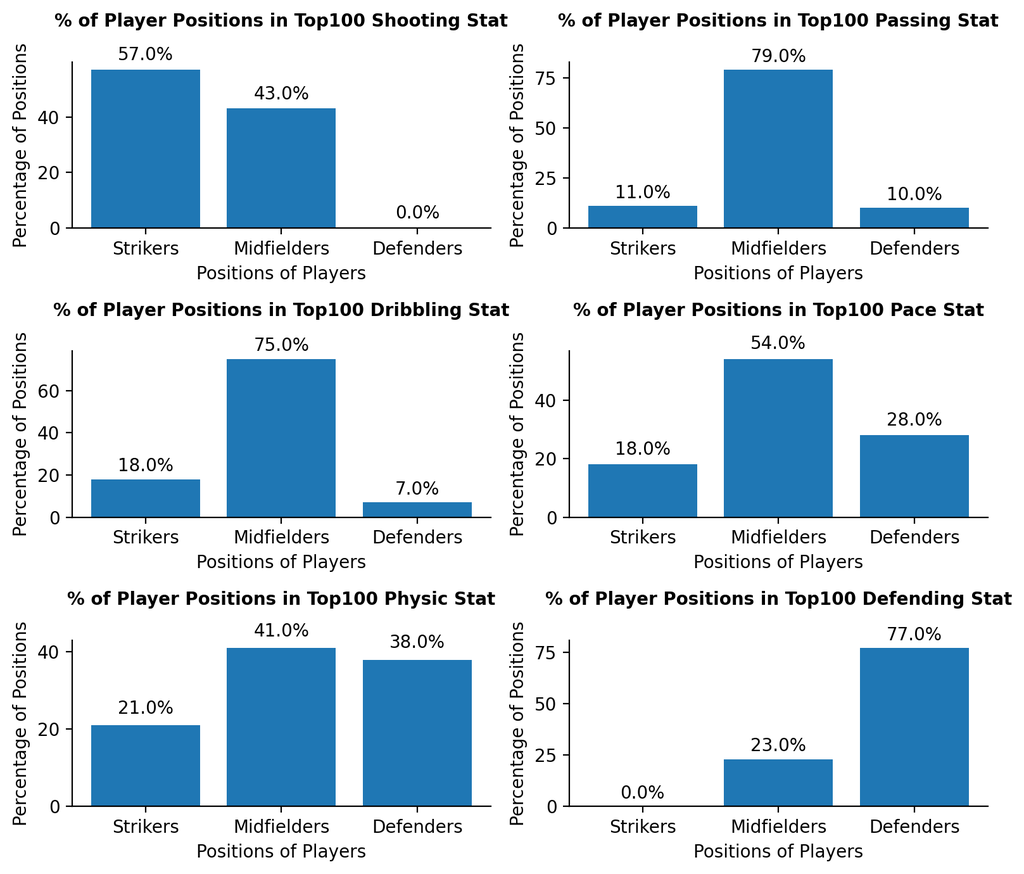

```python
# Define our data.
positions = ['Strikers', 'Midfielders', 'Defenders']
percentages_shoot = [shoot_attack, shoot_mid, shoot_defend]
percentages_pass = [pass_attack, pass_mid, pass_defend]
percentages_dribble = [dribble_attack, dribble_mid, dribble_defend]
percentages_pace = [pace_attack, pace_mid, pace_defend]
percentages_physic = [physic_attack, physic_mid, physic_defend]
percentages_defend = [defend_attack, defend_mid, defend_defend]

# Plot the distribution of positions for Shooting.
fig, axs = plt.subplots(3,2, figsize=[8,7])
axs[0,0].bar(positions, percentages_shoot)
for i, value in enumerate(percentages_shoot):
    axs[0, 0].text(i, value + 2, f"{value}%", ha='center', va='bottom')
axs[0,0].set(xlabel='Positions of Players', ylabel='Percentage of Positions')
axs[0,0].set_title('% of Player Positions in Top100 Shooting Stat', fontweight='bold', pad=20, fontsize=10)
axs[0,0].spines['top'].set_visible(False)
axs[0,0].spines['right'].set_visible(False)

# Plot the distribution of positions for Passing.
axs[0,1].bar(positions, percentages_pass)
for i, value in enumerate(percentages_pass):
    axs[0, 1].text(i, value + 2, f"{value}%", ha='center', va='bottom')
axs[0,1].set(xlabel='Positions of Players', ylabel='Percentage of Positions')
axs[0,1].set_title('% of Player Positions in Top100 Passing Stat', fontweight='bold', pad=20, fontsize=10)
axs[0,1].spines['top'].set_visible(False)
axs[0,1].spines['right'].set_visible(False)

# Plot the distribution of positions for Dribbling.
axs[1,0].bar(positions, percentages_dribble)
for i, value in enumerate(percentages_dribble):
    axs[1, 0].text(i, value + 2, f"{value}%", ha='center', va='bottom')
axs[1,0].set(xlabel='Positions of Players', ylabel='Percentage of Positions')
axs[1,0].set_title('% of Player Positions in Top100 Dribbling Stat', fontweight='bold', pad=20, fontsize=10)
axs[1,0].spines['top'].set_visible(False)
axs[1,0].spines['right'].set_visible(False)

# Plot the distribution of positions for Pace.
axs[1,1].bar(positions, percentages_pace)
for i, value in enumerate(percentages_pace):
    axs[1, 1].text(i, value + 2, f"{value}%", ha='center', va='bottom')
axs[1,1].set(xlabel='Positions of Players', ylabel='Percentage of Positions')
axs[1,1].set_title('% of Player Positions in Top100 Pace Stat', fontweight='bold', pad=20, fontsize=10)
axs[1,1].spines['top'].set_visible(False)
axs[1,1].spines['right'].set_visible(False)

# Plot the distribution of positions for Physic.
axs[2,0].bar(positions, percentages_physic)
for i, value in enumerate(percentages_physic):
    axs[2, 0].text(i, value + 2, f"{value}%", ha='center', va='bottom')
axs[2,0].set(xlabel='Positions of Players', ylabel='Percentage of Positions')
axs[2,0].set_title('% of Player Positions in Top100 Physic Stat', fontweight='bold', pad=20, fontsize=10)
axs[2,0].spines['top'].set_visible(False)
axs[2,0].spines['right'].set_visible(False)

# Plot the distribution of positions for Defending.
axs[2,1].bar(positions, percentages_defend)
for i, value in enumerate(percentages_defend):
    axs[2, 1].text(i, value + 2, f"{value}%", ha='center', va='bottom')
axs[2,1].set(xlabel='Positions of Players', ylabel='Percentage of Positions')
axs[2,1].set_title('% of Player Positions in Top100 Defending Stat', fontweight='bold', pad=20, fontsize=10)
axs[2,1].spines['top'].set_visible(False)
axs[2,1].spines['right'].set_visible(False)

plt.tight_layout()
plt.show()
```

### Which Positions Are Dominant For Each Statistic?

In shooting and defending, we see that the greatest biases in player positions are present, as 0% of defenders are ranked in the top 100 for shooting, while 0% of strikers are ranked in the top 100 for defending. This makes sense because compared to other statistics, they can be considered the most "extreme" statistic due to their importance for specific positions. Meanwhile, midfielders dominate in other statistics, especially passing, dribbling, and pace, as they require the most running and utilization of those skills.

So, because midfielders dominate in most statistics, let's see if the same trend occurs for the top 100 players of the entire *df_filt* data frame.

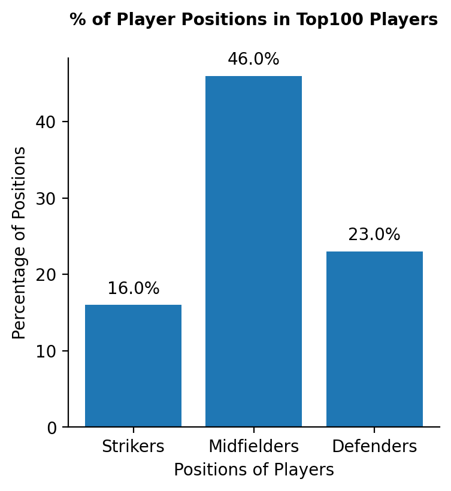

```python
# Retrieve top 100 players in the df_filt data frame. Then, calculate the proportions of each position.
top_100_general = df_filt.head(100)
general_attack = round(top_100_general['club_position'].isin(Attack).sum() /
                 top_100_general['club_position'].count() * 100, 0)
general_mid = round(top_100_general['club_position'].isin(Mid).sum()/
                 top_100_general['club_position'].count()*100,0)
general_defend = round(top_100_general['club_position'].isin(Defend).sum()/
                 top_100_general['club_position'].count()*100,0)
general_percentages = [general_attack, general_mid, general_defend]

# Plot the distribution.
fig, axs = plt.subplots(figsize=[4,4])
axs.bar(positions, general_percentages)
for i, value in enumerate(general_percentages):
    axs.text(i, value + 1, f"{value}%", ha='center', va='bottom')
axs.set(xlabel='Positions of Players', ylabel='Percentage of Positions')
axs.set_title('% of Player Positions in Top100 Players', fontweight='bold', pad=20, fontsize=10)
axs.spines['top'].set_visible(False)
axs.spines['right'].set_visible(False)
plt.show()
```

As expected, we see that midfielders dominate among the top 100 players in the data frame.

### Detailed Statistic vs General Statistic

As previously described, the *df_filt* data frame contains detailed statistics such as *"attacking finishing"* and *"skill ball control"* that are not visible on the FIFA cards. To address the frequent questions regarding how the statistics are calculated, we hypothesized that the average of detailed statistics would align with the values of general statistics.

```python
# Retrieve the top 10 players for shooting
shoot10 = df_filt[df_filt['player_positions']!='GK'].sort_values('shooting', ascending=False).head(10)

# Calculate the average detailed stat for shooting.
shoot10['Average Shooting'] = shoot10[['attacking_finishing','attacking_volleys','power_shot_power',
                                       'skill_fk_accuracy','power_long_shots']].mean(axis=1)

# Create the "Difference" column.
shoot10['Difference'] = shoot10['shooting'] - shoot10['Average Shooting']

# Display the data.
print('Comparing Shooting Stats')
display(shoot10[['short_name','shooting','Average Shooting', 'Difference']])
```

```
Comparing Shooting Stats
```

| Rank | short_name | shooting | Average Shooting | Difference |
| --- | --- | --- | --- | --- |
| 3 | Cristiano Ronaldo | 94.0 | 90.4 | 3.6 |
| 1 | L. Messi | 92.0 | 91.4 | 0.6 |
| 2 | R. Lewandowski | 92.0 | 89.2 | 2.8 |
| 10 | H. Kane | 91.0 | 84.8 | 6.2 |
| 23 | E. Haaland | 91.0 | 85.0 | 6.0 |
| 27 | L. Suarez | 90.0 | 88.4 | 1.6 |
| 39 | S. Aguero | 89.0 | 84.8 | 4.2 |
| 7 | K. Mbappe | 88.0 | 82.6 | 5.4 |
| 16 | M. Salah | 87.0 | 81.4 | 5.6 |
| 25 | R. Lukaku | 87.0 | 79.8 | 7.2 |

```python
# Retrieve the top 10 players for passing
passing10 = df_filt[df_filt['player_positions']!='GK'].sort_values('passing', ascending=False).head(10)

# Calculate the average detailed stat for passing.
passing10['Average Passing'] = round(passing10[['attacking_crossing','attacking_short_passing', 'skill_long_passing',
                                                'mentality_vision']].mean(axis=1),0)

# Create the "Difference" column.
passing10['Difference'] = passing10['passing'] - passing10['Average Passing']

# Display the data.
print('Comparing Passing Stats')
display(passing10[['short_name','passing','Average Passing', 'Difference']])
```

```
Comparing Passing Stats
```

| Rank | short_name | passing | Average Passing | Difference |
| --- | --- | --- | --- | --- |
| 5 | K. De Bruyne | 93.0 | 94.0 | -1.0 |
| 1 | L. Messi | 91.0 | 90.0 | 1.0 |
| 26 | T. Kroos | 91.0 | 91.0 | 0.0 |
| 61 | Parejo | 90.0 | 89.0 | 1.0 |
| 42 | L. Modrić | 89.0 | 89.0 | 0.0 |
| 24 | Bruno Fernandes | 89.0 | 89.0 | 0.0 |
| 32 | T. Alexander-Arnold | 88.0 | 89.0 | -1.0 |
| 29 | M. Verratti | 87.0 | 88.0 | -1.0 |
| 81 | David Silva | 87.0 | 86.0 | 1.0 |
| 67 | Jorginho | 86.0 | 86.0 | 0.0 |

```python
# Retrieve the top 10 players for dribbling.
dribbling10 = df_filt[df_filt['player_positions']!='GK'].sort_values('dribbling', ascending=False).head(10)

# Calculate the average detailed stat for dribbling.
dribbling10['Average Dribbling'] = round(dribbling10[['skill_ball_control','skill_dribbling']].mean(axis=1),0)

# Create the "Difference" column.
dribbling10['Difference'] = dribbling10['dribbling'] - dribbling10['Average Dribbling']

# Display the data.
print('Comparing Dribbling Stats')
display(dribbling10[['short_name','dribbling','Average Dribbling', 'Difference']])
```

```
Comparing Dribbling Stats
```

| Rank | short_name | dribbling | Average Dribbling | Difference |
| --- | --- | --- | --- | --- |
| 1 | L. Messi | 95.0 | 96.0 | -1.0 |
| 4 | Neymar Jr | 94.0 | 95.0 | -1.0 |
| 7 | K. Mbappe | 92.0 | 92.0 | 0.0 |
| 31 | J. Sancho | 91.0 | 91.0 | 0.0 |
| 29 | M. Verratti | 91.0 | 92.0 | -1.0 |
| 37 | P. Dybala | 90.0 | 92.0 | -2.0 |
| 16 | M. Salah | 90.0 | 90.0 | 0.0 |
| 50 | R. Mahrez | 90.0 | 91.0 | -1.0 |
| 55 | Thiago | 90.0 | 91.0 | -1.0 |
| 63 | L. Insigne | 90.0 | 92.0 | -2.0 |

```python
# Retrieve the top 10 players for defending.
defending10 = df_filt[df_filt['player_positions']!='GK'].sort_values('defending', ascending=False).head(10)

# Calculate the average detailed stat for defending.
defending10['Average Defending'] = round(defending10[['defending_marking_awareness','defending_standing_tackle',
                                                      'defending_sliding_tackle']].mean(axis=1),0)

# Create the "Difference" column.
defending10['Difference'] = defending10['defending'] - defending10['Average Defending']

# Display the data.
print('Comparing Defending Stats')
display(defending10[['short_name','defending','Average Defending', 'Difference']])
```

```
Comparing Defending Stats
```

| Rank | short_name | defending | Average Defending | Difference |
| --- | --- | --- | --- | --- |
| 18 | V. van Dijk | 91.0 | 90.0 | 1.0 |
| 59 | M. Hummels | 89.0 | 89.0 | 0.0 |
| 36 | Marquinhos | 89.0 | 89.0 | 0.0 |
| 30 | Ruben Dias | 88.0 | 88.0 | 0.0 |
| 28 | Sergio Ramos | 88.0 | 88.0 | 0.0 |
| 64 | W. Ndidi | 87.0 | 87.0 | 0.0 |
| 120 | S. Savić | 87.0 | 86.0 | 1.0 |
| 56 | K. Koulibaly | 87.0 | 88.0 | -1.0 |
| 54 | R. Varane | 87.0 | 87.0 | 0.0 |
| 76 | S. de Vrij | 87.0 | 87.0 | 0.0 |

```python
# Retrieve the top 10 players for physic.
physic10 = df_filt[df_filt['player_positions']!='GK'].sort_values('physic', ascending=False).head(10)

# Calculate the average detailed stat for physic.
physic10['Average Physic'] = round(physic10[['power_jumping','power_stamina','power_strength']].mean(axis=1),0)

# Create the "Difference" column.
physic10['Difference'] = physic10['physic'] - physic10['Average Physic']

# Display the data.
print('Comparing Physic Stats')
display(physic10[['short_name','physic','Average Physic', 'Difference']])
```

```
Comparing Physic Stats
```

| Rank | short_name | physic | Average Physic | Difference |
| --- | --- | --- | --- | --- |
| 22 | Casemiro | 90.0 | 89.0 | 1.0 |
| 374 | G. Kondogbia | 89.0 | 85.0 | 4.0 |
| 30 | Ruben Dias | 88.0 | 85.0 | 3.0 |
| 268 | Capa | 88.0 | 87.0 | 1.0 |
| 23 | E. Haaland | 88.0 | 83.0 | 5.0 |
| 103 | F. Kessié | 87.0 | 84.0 | 3.0 |
| 70 | M. de Ligt | 87.0 | 87.0 | 0.0 |
| 428 | M. Sissoko | 87.0 | 82.0 | 5.0 |
| 118 | H. Maguire | 87.0 | 86.0 | 1.0 |
| 657 | Fali | 87.0 | 81.0 | 6.0 |

```python
# Retrieve the top 10 players for pace.
pace10 = df_filt[df_filt['player_positions']!='GK'].sort_values('pace', ascending=False).head(10)

# Calculate the average detailed stat for pace.
pace10['Average Pace'] = round(pace10[['movement_acceleration','movement_sprint_speed','movement_agility',
                                       'movement_reactions','movement_balance']].mean(axis=1),0)

# Create the "Difference" column.
pace10['Difference'] = pace10['pace'] - pace10['Average Pace']

# Display the data.
print('Comparing Pace Stats')
display(pace10[['short_name', 'pace','Average Pace','Difference']])
```

```
Comparing Pace Stats
```

| Rank | short_name | pace | Average Pace | Difference |
| --- | --- | --- | --- | --- |
| 7 | K. Mbappe | 97.0 | 92.0 | 5.0 |
| 405 | Adama Traoré | 96.0 | 86.0 | 10.0 |
| 174 | A. Davies | 96.0 | 88.0 | 8.0 |
| 73 | A. Hakimi | 95.0 | 88.0 | 7.0 |
| 918 | G. Holtmann | 94.0 | 79.0 | 15.0 |
| 221 | M. Diaby | 94.0 | 90.0 | 4.0 |
| 210 | Iñaki Williams | 94.0 | 82.0 | 12.0 |
| 421 | I. Sarr | 94.0 | 83.0 | 11.0 |
| 133 | O. Dembélé | 93.0 | 87.0 | 6.0 |
| 378 | Gelson Martins | 93.0 | 88.0 | 5.0 |

### Discrepancies Between Detailed Stat vs General Stat

From the tables, we can see there are some discrepancies between the average detailed statistics and the general statistics. To get a better understanding, let’s first calculate the average of these differences and identify any large differences.

```python
# Determine the mean difference.
print(f'The average difference of pace stat is: {np.abs(pace10["Difference"]).mean()}')
print(f'The average difference of shooting stat is: {round(np.abs(shoot10["Difference"]).mean(),2)}')
print(f'The average difference of physic stat is: {np.abs(physic10["Difference"]).mean()}')
print(f'The average difference of passing stat is: {np.abs(passing10["Difference"]).mean()}')
print(f'The average difference of dribbling stat is: {np.abs(dribbling10["Difference"]).mean()}')
print(f'The average difference of defending stat is: {np.abs(defending10["Difference"]).mean()}')
```

```
The average difference of pace stat is: 8.3
The average difference of shooting stat is: 4.32
The average difference of physic stat is: 2.9
The average difference of passing stat is: 0.6
The average difference of dribbling stat is: 0.9
The average difference of defending stat is: 0.3
```

### What Do We Observe?

The values show that pace, shooting, and physic have large mean differences between the general statistics and detailed statstics, while passing, dribbling, and defending are not as significant. To understand why this may be the case, we will focus on players whose differences exceed the average difference for each general statistic. By identifying those who deviate most from the typical trend, we hope to reveal interesting patterns or anomalies contributing to these larger differences.

It is important to mention that the general statistic column will be highlighted in orange, while the detailed statistic columns with values significantly different from the general statistic column will be highlighted in sky blue. We will define a large difference as a difference greater than 10.

```python
# Retrieve players that have greater value in the Difference column that the mean for pace.
pace_difference_high = pace10[pace10['Difference']>8.3]
pace_difference_high = pace_difference_high[['short_name', 'movement_acceleration','movement_sprint_speed','movement_agility',
                      'movement_reactions','movement_balance', 'Average Pace', 'pace', 'Difference']]

# Define the highlighting function to highlight rows of interest
def highlight_columns(col):
    if col.name in ['movement_balance', 'movement_reactions', 'movement_agility']:
        color = 'skyblue'
    elif col.name in ['pace']:
        color = 'orange'
    else:
        color = 'white'
    return ['background-color: {}'.format(color) for _ in col]

# Ensuring that all values are displayed cleanly
pace_difference_high['pace'] = pace_difference_high['pace'].astype(int)
pace_difference_high['Average Pace'] = pace_difference_high['Average Pace'].astype(int)
pace_difference_high['Difference'] = pace_difference_high['Difference'].astype(int)

# Apply styling to the DataFrame
styled_pace = pace_difference_high.style.apply(highlight_columns)

# Display the data
print('Detailed View of Pace')
styled_pace
```

```
Detailed View of Pace
```

| Rank | short_name | movement_acceleration | movement_sprint_speed | movement_agility | movement_reactions | movement_balance | Average Pace | pace | Difference |
| --- | --- | --- | --- | --- | --- | --- | --- | --- | --- |
| 405 | Adama Traoré | 97 | 96 | 85 | 66 | 88 | 86 | 96 | 10 |
| 918 | G. Holtmann | 93 | 95 | 73 | 67 | 69 | 79 | 94 | 15 |
| 210 | Iñaki Williams | 93 | 94 | 78 | 82 | 62 | 82 | 94 | 12 |
| 421 | I. Sarr | 94 | 94 | 78 | 76 | 74 | 83 | 94 | 11 |

```python
# Retrieve players that have greater value in the Difference column that the mean for shooting.
shoot_difference_high = shoot10[shoot10['Difference']>4.3]
shoot_difference_high = shoot_difference_high[['short_name', 'attacking_finishing', 'attacking_volleys', 'power_shot_power',
                       'skill_fk_accuracy', 'power_long_shots', 'Average Shooting', 'shooting', 'Difference']]

# Define the highlighting function to highlight rows of interest
def highlight_columns(col):
    if col.name == 'skill_fk_accuracy':
        color = 'skyblue'
    elif col.name in ['shooting']:
        color = 'orange'
    else:
        color = 'white'
    return ['background-color: {}'.format(color) for _ in col]

# Ensuring that all values are displayed cleanly
shoot_difference_high['shooting'] = shoot_difference_high['shooting'].astype(int)
shoot_difference_high['Average Shooting'] = shoot_difference_high['Average Shooting'].astype(int)
shoot_difference_high['Difference'] = shoot_difference_high['Difference'].astype(int)

# Apply styling to the DataFrame
styled_shoot = shoot_difference_high.style.apply(highlight_columns)

# Display the data
print('Detailed View of Shooting')
styled_shoot
```

```
Detailed View of Shooting
```

| Rank | short_name | attacking_finishing | attacking_volleys | power_shot_power | skill_fk_accuracy | power_long_shots | Average Shooting | shooting | Difference |
| --- | --- | --- | --- | --- | --- | --- | --- | --- | --- |
| 10 | H. Kane | 94 | 88 | 91 | 65 | 86 | 84 | 91 | 6 |
| 23 | E. Haaland | 94 | 88 | 94 | 62 | 87 | 85 | 91 | 6 |
| 7 | K. Mbappe | 93 | 83 | 86 | 69 | 82 | 82 | 88 | 5 |
| 16 | M. Salah | 91 | 81 | 82 | 69 | 84 | 81 | 87 | 5 |
| 25 | R. Lukaku | 92 | 78 | 89 | 66 | 74 | 79 | 87 | 7 |

```python
# Retrieve players that have greater value in the Difference column that the mean for physic.
physic_difference_high = physic10[physic10['Difference']>2.9]
physic_difference_high = physic_difference_high[['short_name', 'power_jumping','power_stamina',
                        'power_strength','Average Physic', 'physic', 'Difference']]

# Define the highlighting function to highlight rows of interest
def highlight_columns(col):
    if col.name == 'power_jumping':
        color = 'skyblue'
    elif col.name in ['physic']:
        color = 'orange'
    else:
        color = 'white'
    return ['background-color: {}'.format(color) for _ in col]

# Ensuring that all values are displayed cleanly
physic_difference_high['physic'] = physic_difference_high['physic'].astype(int)
physic_difference_high['Average Physic'] = physic_difference_high['Average Physic'].astype(int)
physic_difference_high['Difference'] = physic_difference_high['Difference'].round(1).astype(int)

# Apply styling to the DataFrame
styled_physic = physic_difference_high.style.apply(highlight_columns)

# Display the data
print('Detailed View of Physic')
styled_physic
```

```
Detailed View of Physic
```

| Rank | short_name | power_jumping | power_stamina | power_strength | Average Physic | physic | Difference |
| --- | --- | --- | --- | --- | --- | --- | --- |
| 374 | G. Kondogbia | 79 | 82 | 94 | 85 | 89 | 4 |
| 30 | Ruben Dias | 78 | 88 | 88 | 85 | 88 | 3 |
| 23 | E. Haaland | 74 | 82 | 93 | 83 | 88 | 5 |
| 103 | F. Kessié | 72 | 94 | 86 | 84 | 87 | 3 |
| 428 | M. Sissoko | 70 | 85 | 90 | 82 | 87 | 5 |
| 657 | Fali | 72 | 82 | 90 | 81 | 87 | 6 |

```python
# Retrieve players that have greater value in the Difference column that the mean for passing.
passing_difference_low = passing10[passing10['Difference']>0.6]
print('Detailed View of Passing')
passing_difference_low[['short_name', 'attacking_crossing','attacking_short_passing',
                        'skill_long_passing','mentality_vision', 'Average Passing', 'passing',
                        'Difference']]
```

```
Detailed View of Passing
```

| Rank | short_name | attacking_crossing | attacking_short_passing | skill_long_passing | mentality_vision | Average Passing | passing | Difference |
| --- | --- | --- | --- | --- | --- | --- | --- | --- |
| 1 | L. Messi | 85 | 91 | 91 | 95 | 90.0 | 91.0 | 1.0 |
| 61 | Parejo | 86 | 92 | 90 | 89 | 89.0 | 90.0 | 1.0 |
| 81 | David Silva | 83 | 90 | 83 | 90 | 86.0 | 87.0 | 1.0 |

```python
# Retrieve players that have greater value in the Difference column that the mean for dribbling.
dribbling_difference_low = dribbling10[np.abs(dribbling10['Difference'])>0.9]
print('Detailed View of Dribbling')
dribbling_difference_low[['short_name', 'skill_ball_control','skill_dribbling', 'Average Dribbling', 'dribbling',
                        'Difference']]
```

```
Detailed View of Dribbling
```

| Rank | short_name | skill_ball_control | skill_dribbling | Average Dribbling | dribbling | Difference |
| --- | --- | --- | --- | --- | --- | --- |
| 1 | L. Messi | 96 | 96 | 96.0 | 95.0 | -1.0 |
| 4 | Neymar Jr | 95 | 95 | 95.0 | 94.0 | -1.0 |
| 29 | M. Verratti | 92 | 91 | 92.0 | 91.0 | -1.0 |
| 37 | P. Dybala | 93 | 90 | 92.0 | 90.0 | -2.0 |
| 50 | R. Mahrez | 91 | 91 | 91.0 | 90.0 | -1.0 |
| 55 | Thiago | 92 | 90 | 91.0 | 90.0 | -1.0 |
| 63 | L. Insigne | 93 | 90 | 92.0 | 90.0 | -2.0 |

```python
# Retrieve players that have greater value in the Difference column that the mean for defending.
defending_difference_low = defending10[np.abs(defending10['Difference'])>0.3]
print('Detailed View of Defending')
defending_difference_low[['short_name', 'defending_marking_awareness','defending_standing_tackle','defending_sliding_tackle',
                          'Average Defending', 'defending', 'Difference']]
```

```
Detailed View of Defending
```

| Rank | short_name | defending_marking_awareness | defending_standing_tackle | defending_sliding_tackle | Average Defending | defending | Difference |
| --- | --- | --- | --- | --- | --- | --- | --- |
| 18 | V. van Dijk | 92 | 92 | 86 | 90.0 | 91.0 | 1.0 |
| 120 | S. Savić | 90 | 86 | 83 | 86.0 | 87.0 | 1.0 |
| 56 | K. Koulibaly | 90 | 88 | 86 | 88.0 | 87.0 | -1.0 |

### Conclusion

As the coloured rows show, statistics with large differences, such as pace, shooting, and physic, tend to include at least one detailed statistic that deviates significantly from the others and its corresponding general statistic. In contrast, statistics with smaller differences, like passing, dribbling, and defending, are composed of detailed statistics that are relatively consistent.

This observation suggests that the general statistic is likely not calculated as a simple average of the detailed statistics, especially for categories with large differences. Instead, each detailed statistic is likely assigned a different weight or proportion in the calculation, reflecting its relative importance in contributing to the overall value.

## Analysis 2: Relationship Between Overall Rating and 6 General Statistics

In addition to the general statistics, the overall rating is also a controversial metric whose origins many people question. To understand how the overall rating may be derived, we will follow these steps of analysis:

1. Calculate the average of the 6 general statistics.
2. Compare this value with the overall rating to determine if they match.
3. If they do not match, analyze how the overall rating varies under different circumstances and identify a potential method for its calculation.

### Calculating Average of 6 General Statistics

To accomplish this step, we will create a column named *average_data* in the *df_filt* data frame to store each player's calculated average general statistic. It is important to note that goalkeepers and non-goalkeepers have different statistical categories. Therefore, we need to calculate the averages using two distinct procedures to account for these differences.

```python
# Create average_data for non-goalkeepers.
df_filt['average_data'] = round(
    df_filt.loc[df_filt['club_position'] != 'GK', ['pace', 'shooting', 'passing',
                                                   'dribbling', 'defending', 'physic']].mean(axis=1), 0)
```

By checking for any missing value in the *average_data* column, we see that the columns with club position as GK have NaN. As previously described, this is because goalkeepers have separate general ratings.

```python
# Check for missing values
df_filt[df_filt['average_data'].isna()][['short_name', 'club_position', 'average_data']]
```

| Rank | short_name | club_position | average_data |
| --- | --- | --- | --- |
| 6 | J. Oblak | GK | NaN |
| 8 | M. Neuer | GK | NaN |
| 9 | M. ter Stegen | GK | NaN |
| 13 | G. Donnarumma | GK | NaN |
| 14 | Alisson | GK | NaN |
| ... | ... | ... | ... |
| 983 | G. Vicario | GK | NaN |
| 1015 | Aarón | GK | NaN |
| 1017 | L. Lezzerini | GK | NaN |
| 1019 | V. Milinković-Savić | GK | NaN |
| 1021 | D. Bachmann | GK | NaN |

98 rows × 3 columns

```python
# Create average_data for non-goalkeepers.
df_filt.loc[df_filt['club_position'] == 'GK', 'average_data'] = round(
    df_filt.loc[df_filt['club_position'] == 'GK', ['goalkeeping_diving', 'goalkeeping_handling', 'goalkeeping_kicking',
                                                      'goalkeeping_positioning', 'goalkeeping_reflexes',
                                                   'goalkeeping_speed']].mean(axis=1), 0)
df_filt['average_data'] = df_filt['average_data'].astype(int)
```

```python
# Check for missing values.
df_filt[df_filt['average_data'].isna()]
```

|  | short_name | long_name | player_positions | overall | potential | value_eur | wage_eur | age | height_cm | weight_kg | ... | defending_standing_tackle | defending_sliding_tackle | goalkeeping_diving | goalkeeping_handling | goalkeeping_kicking | goalkeeping_positioning | goalkeeping_reflexes | goalkeeping_speed | club_rank | average_data |
| --- | --- | --- | --- | --- | --- | --- | --- | --- | --- | --- | --- | --- | --- | --- | --- | --- | --- | --- | --- | --- | --- |
| Rank |  |  |  |  |  |  |  |  |  |  |  |  |  |  |  |  |  |  |  |  |  |

0 rows × 67 columns

Now, we see that there are no missing values in the *average_data* column.

### Comparing Overall vs Average Data

To analyze how different the overall rating is from the averaged value, we will first see what proportions of average data are smaller, equal to, or larger than the overall rating.

```python
print('The proportion that are equal is:',
      round((df_filt['overall'] == df_filt['average_data']).sum()/(df_filt['average_data']).count() * 100,1))
print('The proportion that are greater is:',
      round((df_filt['overall'] > df_filt['average_data']).sum()/(df_filt['average_data']).count() * 100,1))
print('The proportion that are less is:',
      round((df_filt['overall'] < df_filt['average_data']).sum()/(df_filt['average_data']).count() * 100,1))
```

```
The proportion that are equal is: 0.1
The proportion that are greater is: 99.7
The proportion that are less is: 0.2
```

### Taking a Closer Look

Based on the calculations, 99.7% of players have an overall rating higher than the average of their six general statistics. Meanwhile, 0.1% have an overall rating equal to the average, and only 0.2% have an overall rating lower than the average.

So, let's examine the small proportion of players whose overall ratings are equal to or less than the average of their general statistics.

```python
df_filt[df_filt['overall'] <= df_filt['average_data']][['short_name', 'overall','average_data', 'club_name',
                                                        'league_name', 'club_position', 'club_rank']]
```

| Rank | short_name | overall | average_data | club_name | league_name | club_position | club_rank |
| --- | --- | --- | --- | --- | --- | --- | --- |
| 886 | W. Cyprien | 73 | 73 | FC Nantes | French Ligue 1 | RDM | 9 |
| 933 | O. Etebo | 72 | 73 | Watford | English Premier League | CDM | 19 |
| 943 | J. Obi | 72 | 74 | US Salernitana 1919 | Italian Serie A | LCM | 17 |

We observe that players whose overall ratings are equal to or lower than their average data are part of teams that finished in the middle or near the bottom of the table (e.g., the club ranks 9/20, 19/20, and 17/20) during the 2021-22 season. Specifically, players with lower overall ratings than their average data belong to lower-ranked teams than the player with equal ratings.

To explore this further, let’s examine whether, in general, the difference between the average data and the overall rating is greater for players in the top 5 teams of the 5 European leagues compared to those in the bottom 5 teams. For this analysis, we will create two data frames named *top_5_teams* and *bottom_5_teams*, which include all teams that finished in the top 5 and the bottom 5 of their respective leagues.

```python
# Define top 5 and bottom 5 teams in the leagues. (German league has 18 teams unlike others who have 20).
top_5_teams = df_filt[df_filt['club_rank']<=5]
bottom_5_teams = df_filt[
    ((df_filt['league_name'] == 'German 1. Bundesliga') & (df_filt['club_rank'] >= 14)) |
    ((df_filt['league_name'] != 'German 1. Bundesliga') & (df_filt['club_rank'] >= 16))]
```

Now that we have created the two data frames, we will calculate the difference between the overall rating and the average general statistics data for each player and store the results in a new column named *difference*. Then, we will groupby league name to compare the mean difference value between leagues.

```python
# Determine the difference between overall rating and average data for top 5 teams.
top_5_teams['difference'] = top_5_teams['overall'] - top_5_teams['average_data']
top_result = top_5_teams.groupby('league_name')['difference'].mean().sort_values(ascending=False)
print(top_result)

# Determine the difference between overall rating and average data for bottom 5 teams.
bottom_5_teams['difference'] = bottom_5_teams['overall'] - bottom_5_teams['average_data']

# Reorganize the index to match the order of the top_result data.
bottom_result = bottom_5_teams.groupby('league_name')['difference'].mean().reindex(['English Premier League',
                                                                                    'Spain Primera Division',
                                                                                    'German 1. Bundesliga', 'Italian Serie A',
                                                                                    'French Ligue 1'])
print(bottom_result)
```

```
league_name
English Premier League    10.200000
Spain Primera Division    10.200000
German 1. Bundesliga       9.745455
Italian Serie A            9.654545
French Ligue 1             9.036364
Name: difference, dtype: float64
league_name
English Premier League    8.672727
Spain Primera Division    8.854545
German 1. Bundesliga      7.981818
Italian Serie A           8.690909
French Ligue 1            8.490909
Name: difference, dtype: float64
```

### Plotting the Difference

Let's plot the outputs to better visualize the trends and differences.

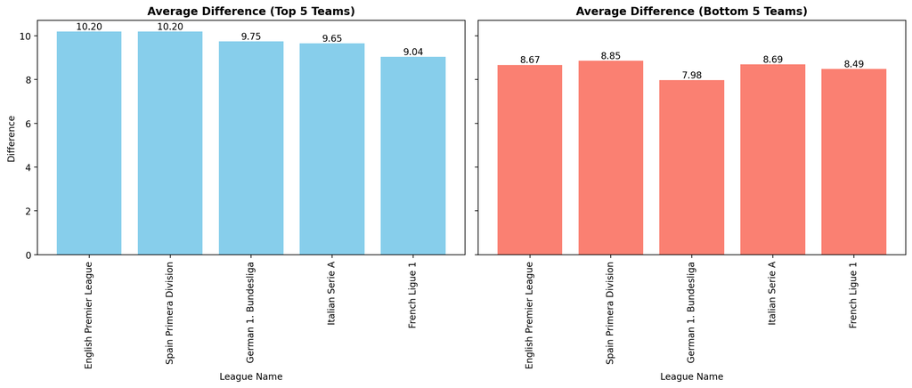

```python
# Plotting the values of differences.
fig, axs = plt.subplots(1, 2, figsize=(14, 6), sharey=True)

axs[0].bar(top_result.index, top_result.values, color='skyblue')
axs[0].set_title("Average Difference (Top 5 Teams)", fontweight='bold')
axs[0].set_xlabel("League Name")
axs[0].set_ylabel("Difference")
axs[0].tick_params(axis='x', rotation=90)
for i, value in enumerate(top_result.values):
    axs[0].text(i, value, f"{value:.2f}", ha='center', va='bottom', fontsize=10)

axs[1].bar(bottom_result.index, bottom_result.values, color='salmon')
axs[1].set_title("Average Difference (Bottom 5 Teams)",fontweight='bold')
axs[1].set_xlabel("League Name")
axs[1].tick_params(axis='x', rotation=90)
for i, value in enumerate(bottom_result.values):
    axs[1].text(i, value, f"{value:.2f}", ha='center', va='bottom', fontsize=10)

plt.tight_layout()
plt.show()
```

### What Can We Learn From This?

As expected from our previous analysis, both figures show that the overall rating is greater than the average of the general statistics. However, we observe that players from top-ranked teams exhibit a greater difference compared to low-ranked teams. Furthermore, while the differences among players from low-ranked teams are relatively consistent, the degree of difference for players on top teams is ordered the same as the league competitiveness: from most to least competitive—English, Spanish, German, Italian, and French leagues.

This trend may be observed because top teams in more competitive leagues typically generate higher revenue and are more sought after by world-class players. As a result, top teams in these leagues attract elite talent, significantly boosting their overall ratings. This is supported by the figure below, which demonstrates a moderate negative correlation of -0.59 between overall rating and club rank, indicating that as club rank increases (moving to lower-ranked teams), the overall rating of players tends to decrease. Furthermore, we could also infer that players who belong to higher-ranked teams may receive a "boost" in their overall rating because of the prestige and quality associated with their team.

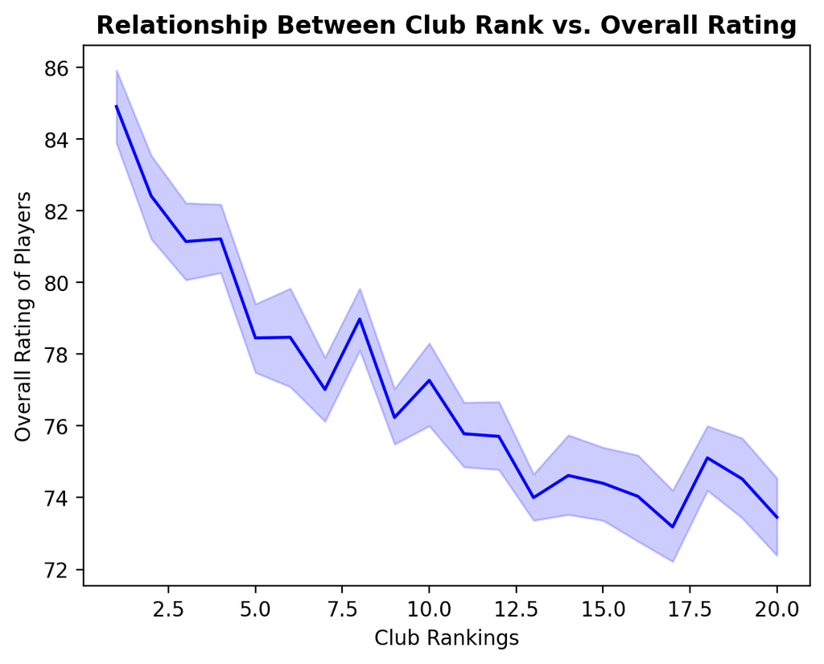

```
Correlation coefficient: -0.59
```

```python
sns.lineplot(data=df_filt, x='club_rank', y='overall', color='blue')
plt.xlabel('Club Rankings')
plt.ylabel('Overall Rating of Players')
plt.title('Relationship Between Club Rank vs. Overall Rating', fontweight='bold')
plt.show()
correlation, p_value = pearsonr(df_filt['club_rank'], df_filt['overall'])
print(f"Correlation coefficient: {round(correlation,2)}")
```

### Comparing Overall vs Average Detailed Statistics

Since our goal is to identify the best calculation method to determine how the overall rating is derived, let's explore whether we can reduce the difference by applying an alternative approach.

Below, we create a new column called *average_detail_data* by grouping players based on their positions: **Attackers**, **Defenders**, or **Goalkeepers**. Then, as we did before, we will retrieve detailed statistics not shown on the FIFA card and calculate averages for relevant statistics based on each position. Finally, we can compare these position-specific averages to each player's overall rating.

```python
# If club position is one of the ones in the series of positions,
# they are considered attackers and will include the detailed statistics below.
df_filt.loc[df_filt['club_position'].str.contains('RM|LM|LCM|RCM|LW|RW|CDM|CAM|CM|LDM|LAM|RAM|RDM|CF|ST|RS|LS|RF|LF', na=False),
'average_detail_data']  = round(df_filt.loc[df_filt['club_position'].str.contains('RM|LM|LCM|RCM|LW|RW|CDM|CAM|CM|LDM|RDM|RAM|LAM|CF|ST|RS|LS|RF|LF', na=False),
    ['attacking_crossing','attacking_finishing','attacking_heading_accuracy','attacking_short_passing',
     'attacking_volleys','skill_dribbling','skill_curve','skill_fk_accuracy','skill_long_passing','skill_ball_control',
     'movement_acceleration','movement_sprint_speed','movement_agility','movement_reactions','movement_balance',
     'power_shot_power','power_jumping','power_stamina','power_strength','power_long_shots','mentality_aggression',
     'mentality_interceptions','mentality_positioning','mentality_vision','mentality_penalties','mentality_composure']].mean(axis=1), 0)
```

```python
# If club position is one of the ones in the series of positions,
# they are considered defenders and will include the detailed statistics below.
df_filt.loc[df_filt['club_position'].str.contains('LCB|RCB|LB|RB|LWB|RWB|CB', na=False), 'average_detail_data'] = round(
    df_filt.loc[df_filt['club_position'].str.contains('LCB|RCB|LB|RB|LWB|RWB|CB', na=False), ['mentality_aggression',
                                                           'mentality_interceptions','mentality_positioning','mentality_vision',
                                                           'mentality_penalties','mentality_composure','defending_marking_awareness',
                                                           'defending_standing_tackle','defending_sliding_tackle']].mean(axis=1), 0)
```

```python
# If club position is one of the ones in the series of positions,
# they are considered goalkeepers and will include the detailed statistics below.
df_filt.loc[df_filt['club_position'] == 'GK', 'average_detail_data'] = round(
    df_filt.loc[df_filt['club_position']=='GK', ['goalkeeping_diving','goalkeeping_handling','goalkeeping_kicking',
                                                    'goalkeeping_positioning','goalkeeping_reflexes']].mean(axis=1), 0)
```

```python
# Check for missing values.
df_filt[df_filt['average_detail_data'].isna()]
```

|  | short_name | long_name | player_positions | overall | potential | value_eur | wage_eur | age | height_cm | weight_kg | ... | defending_sliding_tackle | goalkeeping_diving | goalkeeping_handling | goalkeeping_kicking | goalkeeping_positioning | goalkeeping_reflexes | goalkeeping_speed | club_rank | average_data | average_detail_data |
| --- | --- | --- | --- | --- | --- | --- | --- | --- | --- | --- | --- | --- | --- | --- | --- | --- | --- | --- | --- | --- | --- |
| Rank |  |  |  |  |  |  |  |  |  |  |  |  |  |  |  |  |  |  |  |  |  |

0 rows × 68 columns

After confirming there are no missing values in the column, we’ll again examine the top 5 and bottom 5 teams to compare the differences between players’ overall ratings and their average detailed statistics. To account for the new column added to the df_filt data, we will re-define our *top_5_teams* and *bottom_5_teams* data frames.

```python
# Define top and bottom 5 teams.
top_5_teams = df_filt[df_filt['club_rank']<=5]
bottom_5_teams = df_filt[
    ((df_filt['league_name'] == 'German 1. Bundesliga') & (df_filt['club_rank'] >= 14)) |
    ((df_filt['league_name'] != 'German 1. Bundesliga') & (df_filt['club_rank'] >= 16))
]
```

```python
# Calculate the difference and name it detail difference.
top_5_teams['detail_difference'] = top_5_teams['overall'] - top_5_teams['average_detail_data']
top_result_2 = top_5_teams.groupby('league_name')['detail_difference'].mean().reindex(['English Premier League', 'Spain Primera Division', 'German 1. Bundesliga', 'Italian Serie A','French Ligue 1'])
print(top_result_2)

bottom_5_teams['detail_difference'] = bottom_5_teams['overall'] - bottom_5_teams['average_detail_data']
bottom_result_2 = bottom_5_teams.groupby('league_name')['detail_difference'].mean().reindex(['English Premier League', 'Spain Primera Division', 'German 1. Bundesliga', 'Italian Serie A','French Ligue 1'])
print(bottom_result_2)
```

```
league_name
English Premier League    8.418182
Spain Primera Division    7.909091
German 1. Bundesliga      7.800000
Italian Serie A           8.290909
French Ligue 1            7.290909
Name: detail_difference, dtype: float64
league_name
English Premier League    7.054545
Spain Primera Division    7.454545
German 1. Bundesliga      7.727273
Italian Serie A           7.290909
French Ligue 1            7.472727
Name: detail_difference, dtype: float64
```

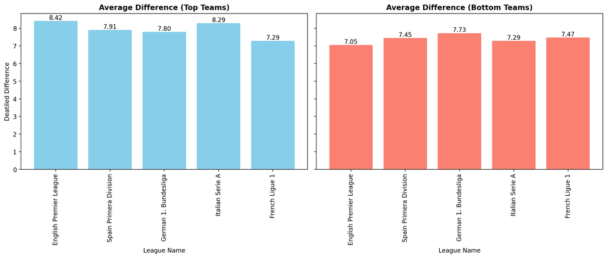

```python
# Plot the values of differences.
fig, axs = plt.subplots(1, 2, figsize=(14, 6), sharey=True)

axs[0].bar(top_result_2.index, top_result_2.values, color='skyblue')
axs[0].set_title("Average Difference (Top Teams)", fontweight='bold')
axs[0].set_xlabel("League Name")
axs[0].set_ylabel("Deatiled Difference")
axs[0].tick_params(axis='x', rotation=90)
for i, value in enumerate(top_result_2.values):
    axs[0].text(i, value, f"{value:.2f}", ha='center', va='bottom', fontsize=10)

axs[1].bar(bottom_result_2.index, bottom_result_2.values, color='salmon')
axs[1].set_title("Average Difference (Bottom Teams)", fontweight='bold')
axs[1].set_xlabel("League Name")
axs[1].tick_params(axis='x', rotation=90)
for i, value in enumerate(bottom_result_2.values):
    axs[1].text(i, value, f"{value:.2f}", ha='center', va='bottom', fontsize=10)

plt.tight_layout()
plt.show()
```

Although the differences have decreased, they are still quite large. The previous trend observed in the top teams where the degree of difference corresponds to the competitiveness of the leagues is primarily present, with the exception of the Italian league. Also, except for the French league, the top teams still hold higher differences.

### Continuing the Journey of Finding Where the Overall Data Comes From

As the overall rating continues to be larger, we attempted to reduce this gap by incorporating the potential boost observed in players from higher-ranked teams into the calculation. This was done by giving a 10-point bonus to the value of the *average_detail_data* for players belonging to the top 5 teams, an 8-point bonus for players of teams ranked between 6 to 10, and assigning 6 points for all other players. We then calculated the difference between the overall rating and this adjusted value, storing the result in a new column named *new_difference*.

```python
# Assign team bonuses
df_filt['team_bonus'] = 0
df_filt.loc[df_filt['club_rank'] <= 5, 'team_bonus'] = 10
df_filt.loc[(df_filt['club_rank'] > 5) & (df_filt['club_rank'] <= 10), 'team_bonus'] = 8
df_filt.loc[df_filt['club_rank'] > 10, 'team_bonus'] = 6

# Calculate new_difference with the team bonus as well as the mean and standard deviation of new_difference.
df_filt['new_difference'] = df_filt['overall'] - (df_filt['average_detail_data'] + df_filt['team_bonus'])
df_filt_result = np.abs(df_filt['new_difference'].mean())
df_filt_result2 = np.abs(df_filt['new_difference'].std())
print('The mean difference after calculation is:', round(df_filt_result, 1))
print('The standard deviation of the difference is:', round(df_filt_result2, 1))
```

```
The mean difference after calculation is: 0.1
The standard deviation of the difference is: 3.7
```

### Conclusion

The calculations yielded a result with a mean difference of 0.1 from the actual overall rating, with a standard deviation of 3.7. This suggests that the approach provides a **reasonable approximation** of the method used to determine the overall rating.

## Analysis 3: Relationship Between Rating and Value of Players

To understand the relationships that may be present between the ratings of the players and their value, we will analyze this through following steps:

1. Plot and analyze the relationship between a player's overall rating and their value.
2. If you rank players by value and overall rating, do they match?
3. How does age influence the value of players?

### Relationship Between Overall Rating and Value of Player

To understand this relationship, we will first plot the relationship between the overall rating and the value of each player. Next, we will extract the top 100 players based on their overall rating from the *df_filt* data frame, creating a new data frame called *top_100*. Finally, we will plot the same relationship using the *top_100* data to identify any differences compared to the full dataset.

It is important to note that player values in the *df_filt* data vary significantly among players. Thus, we will apply a log10 transformation to the values for clearer analysis. However, due to this transformation, the y-axis does not represent the actual player values but rather the ratios between values.

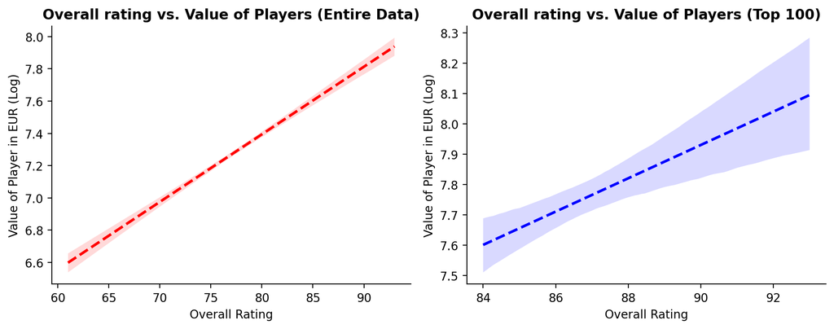

```
Correlation coefficient for entire data is: 0.8
Correlation coefficient for top 100 data is: 0.6
```

```python
# Log the value of players and store the result in log_value column.
df_filt['log_value'] = np.log10(df['value_eur'])

# Extract the top 100 players.
top_100 = df_filt.head(100)

# Plot the relationship for entire data.
fig, axs = plt.subplots(1,2, figsize=[10,4])
sns.regplot(data=df_filt, x='overall', y='log_value', scatter=False, color='red', line_kws={'linestyle': '--'}, ax=axs[0])
axs[0].set_xlabel('Overall Rating')
axs[0].set_ylabel('Value of Player in EUR (Log)')
axs[0].spines['top'].set_visible(False)
axs[0].spines['right'].set_visible(False)
axs[0].set_title('Overall rating vs. Value of Players (Entire Data)', fontweight='bold')

# Plot the relationship for top_100 data. Used log for easier comparison, although not needed for top_100 data.
sns.regplot(data=top_100, x='overall', y='log_value', scatter=False, color='blue', line_kws={'linestyle': '--'}, ax=axs[1])
axs[1].set_xlabel('Overall Rating')
axs[1].set_ylabel('Value of Player in EUR (Log)')
axs[1].spines['top'].set_visible(False)
axs[1].spines['right'].set_visible(False)
axs[1].set_title('Overall rating vs. Value of Players (Top 100)', fontweight='bold')
plt.tight_layout()
plt.show()

# Calculate Pearson correlation coefficient.
correlation1, p_value = pearsonr(df_filt['overall'], df_filt['value_eur'])
correlation2, p_value = pearsonr(top_100['overall'], top_100['value_eur'])
print(f"Correlation coefficient for entire data is: {round(correlation1,2)}")
print(f"Correlation coefficient for top 100 data is: {round(correlation2,2)}")
```

```python
df_filt['value_eur'].max()
```

```
194000000.0
```

Notice how, when transitioning from the entire data frame to the top 100 data, the correlation coefficient decreases from a strong positive correlation of 0.8 to a moderate positive correlation of 0.6. Additionally, the top 100 data plot exhibits greater variance, indicating that the relationship between overall rating and player value becomes less consistent among the highest-rated players.

### If you rank best players by value and overall rating, do they match?

To understand why the relationship between overall rating and player value becomes inconsistent among the highest-rated players, we will focus on the "best players" in the *df_filt* data frame. "Best players" are defined as players whose overall rating and value are considered upper-outliers according to Tukey's method. By analyzing this group, we can better understand the dynamics among elite players and how factors beyond ratings influence their value.

```python
# Determining upper-outlier threshold for overall rating in df_filt.
q1 = df_filt['overall'].quantile(0.25)
q3 = df_filt['overall'].quantile(0.75)
iqr = q3 - q1

out_high = q3 + iqr*1.5
out_low = q1 - iqr*1.5

print(out_high)
```

```
89.0
```

```python
# Determining upper-outlier threshold for value of player in df_filt.
q1 = df_filt['value_eur'].quantile(0.25)
q3 = df_filt['value_eur'].quantile(0.75)
iqr = q3 - q1

out_high = q3 + iqr*1.5
out_low = q1 - iqr*1.5

print(out_high)
```

```
52600000.0
```

We have identified that anything above an overall rating of 89 and a value of €52,600,000 are upper-outliers. Using these thresholds, we can define our best players as those who exceed these values, filtering the dataset accordingly.

```python
# Create a column named "outlier" that contains a Boolean series
df_filt['outlier'] = (df_filt['overall'] > 89) & (df_filt['value_eur'] > 52600000)

# Filter players that have "True" in the outlier column.
df_filt[df_filt['outlier']==True][['overall','short_name','age','value_eur','nationality_name']]
```

| Rank | overall | short_name | age | value_eur | nationality_name |
| --- | --- | --- | --- | --- | --- |
| 1 | 93 | L. Messi | 34 | 78000000.0 | Argentina |
| 2 | 92 | R. Lewandowski | 32 | 119500000.0 | Poland |
| 4 | 91 | Neymar Jr | 29 | 129000000.0 | Brazil |
| 5 | 91 | K. De Bruyne | 30 | 125500000.0 | Belgium |
| 6 | 91 | J. Oblak | 28 | 112000000.0 | Slovenia |
| 7 | 91 | K. Mbappe | 22 | 194000000.0 | France |
| 9 | 90 | M. ter Stegen | 29 | 99000000.0 | Germany |
| 10 | 90 | H. Kane | 27 | 129500000.0 | England |
| 11 | 90 | N. Kante | 30 | 100000000.0 | France |

### Overall Rank vs Value Rank

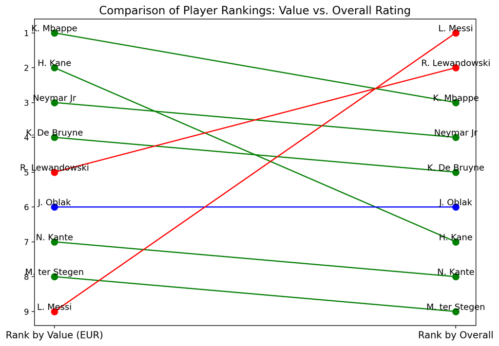

```python
# Create two data frames that rank players based on overall or value. Then, merge the data.
x = df_filt[df_filt['outlier']==True]
x = x.reset_index(drop=True)
x = x.set_index('value_eur').sort_index(ascending=False)
y = x.reset_index()
y = y.set_index('overall').sort_index(ascending=False)
x['rank_value'] = range(1, len(x) + 1)
y['rank_overall'] = range(1, len(y) + 1)
merged = pd.merge(x.reset_index(), y.reset_index(), on='short_name')
merged

# Plot the merged data, and label player names on the markers.
plt.figure(figsize=(10, 7))
for i in range(len(merged)):
    plt.plot([1, 2], [merged['rank_value'].iloc[i], merged['rank_overall'].iloc[i]], marker='o', markersize=8,
        color = ('blue' if merged['rank_value'].iloc[i] == merged['rank_overall'].iloc[i]
         else 'green' if merged['rank_value'].iloc[i] < merged['rank_overall'].iloc[i]
         else 'red'))
    plt.text(1, merged['rank_value'].iloc[i], f'{merged["short_name"].iloc[i]}', va='bottom', ha='center', fontsize=11)
    plt.text(2, merged['rank_overall'].iloc[i], f'{merged["short_name"].iloc[i]}', va='bottom', ha='center', fontsize=11)

plt.xticks([1, 2], ['Rank by Value (EUR)', 'Rank by Overall'], fontsize=12)
plt.title('Comparison of Player Rankings: Value vs. Overall Rating', fontsize=14)

# Invert axis to have Rank 1 on top instead of bottom.
plt.gca().invert_yaxis()
plt.show()
```

From the figure above, we observe a general trend where most players are ranked higher in value compared to their overall rating, with only one player having the same ranking in both categories. This observation aligns with our earlier finding of an inconsistent relationship among top players. However, two players, L. Messi and R. Lewandowski, stand out by being ranked lower in value but higher in overall rating. Let’s take a closer look at these two players to explore this discrepancy further.

```python
# Filtering the two players.
odd = ['L. Messi', 'R. Lewandowski']
odd_players = df_filt[df_filt['short_name'].isin(odd)]
odd_players[['short_name', 'club_position', 'overall', 'potential', 'value_eur', 'age', 'league_name', 'club_name', 'club_position', 'club_rank']]
```

| Rank | short_name | club_position | overall | potential | value_eur | age | league_name | club_name | club_position | club_rank |
| --- | --- | --- | --- | --- | --- | --- | --- | --- | --- | --- |
| 1 | L. Messi | RW | 93 | 93 | 78000000.0 | 34 | French Ligue 1 | Paris Saint-Germain | RW | 1 |
| 2 | R. Lewandowski | ST | 92 | 92 | 119500000.0 | 32 | German 1. Bundesliga | FC Bayern München | ST | 1 |

The key things to notice are:

1. They are considered "old" in terms of professional soccer players but play for best teams in their corresponding leagues.
2. They are the top 2 players in terms of overall rating.

Thus, these factors indicate that these two are great players, but their value may be lower due to their age. So, we will now look at the relationship between the age and value of players and label the two players on the figure.

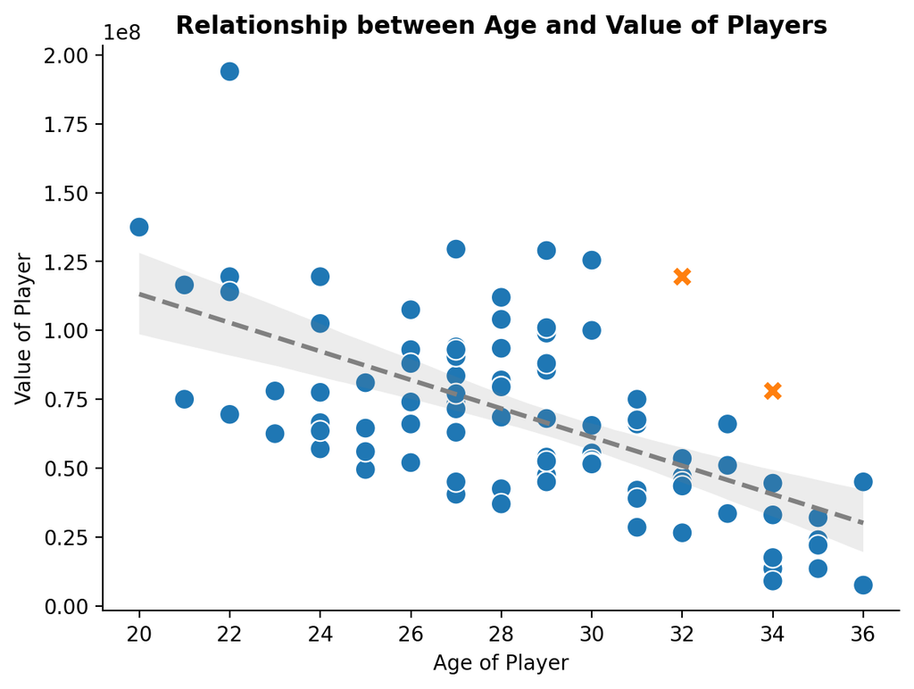

```
Correlation coefficient: -0.6
```

```python
# Plotting relationship between Age vs Value. Two players are labeled.
top_100['Two Players'] = top_100['short_name'].isin(odd)
fig, axs = plt.subplots(figsize=[7,5])
sns.scatterplot(data=top_100, x='age', y='value_eur', s=100, hue = 'Two Players', style='Two Players', ax=axs)
sns.regplot(data=top_100, x='age', y='value_eur', scatter=False, ax=axs, color='gray', line_kws={'linestyle': '--'})
axs.set_xlabel('Age of Player')
axs.set_ylabel('Value of Player')
axs.spines['top'].set_visible(False)
axs.spines['right'].set_visible(False)
axs.set_title('Relationship between Age and Value of Players', fontweight='bold')
plt.legend().remove()
plt.show()

# Calculate Pearson correlation coefficient
correlation, p_value = pearsonr(top_100['age'], top_100['value_eur'])
print(f"Correlation coefficient: {round(correlation,2)}")
```

We see that there is also a moderate negative correlation of -0.6 between the age of players and their value, where an increase in age leads to a decrease in value. Additionally, the two players stand out as the only ones over 30 years old who are significantly above the regression line, meaning their values are much higher than other players of a similar age.

### Conclusion

The general trend of an increase in overall rating leading to greater value is intuitive. However, discrepancies emerged when the best players were ranked by a value relative to their overall rating. This can be attributed to the influence of age, where some older players are assigned lower values despite their strong past and current performance, contributing to high overall ratings. In contrast, younger players in similar forms are valued more highly due to their potential for future growth and longevity in the sport.

## Analysis 4: Relationship Between Wage and Position

Lastly, let's analyze the relationship between the wages of players and their position. We will do this by:

1. Take a look at the distribution of wage in *df_filt* and use this information to either calculate mean or median wage for each position.
2. Retrieve players with top 100 wages in the df_filt data and check which positions dominate within the top 100.
3. Analyze which players are "overpaid" and "underpaid."

### Density Distribution of Wage and Overall Rating

Observing the density distributions below shows that wages are positively skewed, while overall ratings are more normally distributed. To better represent the data, we will use the median for wages, as the median is less affected by outliers and skewed distributions. For overall ratings, which follow a more normal distribution, we will use the mean.

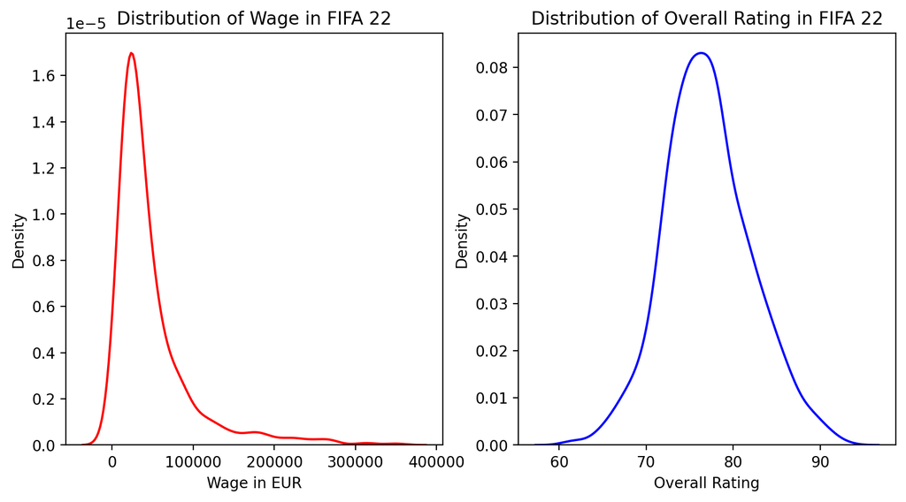

```python
# Plot density distributions for wage and overall rating
fig, axs = plt.subplots(1,2, figsize=[10,5])
sns.kdeplot(data=df_filt, x='wage_eur', color='red', ax=axs[0])
sns.kdeplot(data=df_filt, x='overall', color='blue', ax=axs[1])
axs[0].set_xlabel('Wage in EUR')
axs[0].set_title('Distribution of Wage in FIFA 22')
axs[1].set_xlabel('Overall Rating')
axs[1].set_title('Distribution of Overall Rating in FIFA 22')
plt.show()
```

### Median Wage of Each Position

Now, let’s examine the median wage for each position. Again, for simplicity, we will categorize club positions into four broad groups: **attackers**, **midfielders**, **defenders**, and **goalkeepers**.

```python
# Print the median wage for each position
print(f'The median wage of a attacker in is €{round(df_filt[df_filt["club_position"].str.contains("CF|ST|RS|LS|RF|LF", na=False)]["wage_eur"].median(), 1)}')
print(f'The median wage of a midfielder in EUR is €{round(df_filt[df_filt["club_position"].str.contains("RM|LM|LCM|RCM|LW|RW|CDM|CAM|CM|LDM|RDM", na=False)]["wage_eur"].median(),1)}')
print(f'The median wage of a defender in EUR is €{round(df_filt[df_filt["club_position"].str.contains("LCB|RCB|LB|RB|LWB|RWB|CB", na=False)]["wage_eur"].median(),1)}')
print(f'The median wage of a goalkeeper in EUR is €{round(df_filt[df_filt["club_position"].str.contains("GK", na=False)]["wage_eur"].median(),1)}')
```

```
The median wage of a attacker in is €37000.0
The median wage of a midfielder in EUR is €31000.0
The median wage of a defender in EUR is €27500.0
The median wage of a goalkeeper in EUR is €27000.0
```

Listing positions from highest to lowerst median wage: **attacker -> midfielder -> defender -> goalkeeper**

From this simple analysis, we can potentially assume that outfield positions (attack, mid, def) are favored over goalkeepers. However, to be sure, let's see if this sort of trend is observed among 100 players who earn the most wage.

### Retrieving the Top 100 Wages

We will retrieve 100 players who earn the most in the data and name it *rich_100*.

```python
# Top 100 wages.
rich_100=df_filt.sort_values('wage_eur', ascending=False).head(100)
```

### Position Distribution Within Top 100

Then, we can take a look at how the positions are distributed within the *rich_100* data. We will generalize the categorization of positions into Attacker, Midfielders (Mid), Defenders (Def), and Goalkeeprs (GK). Then, we will plot the distribution.

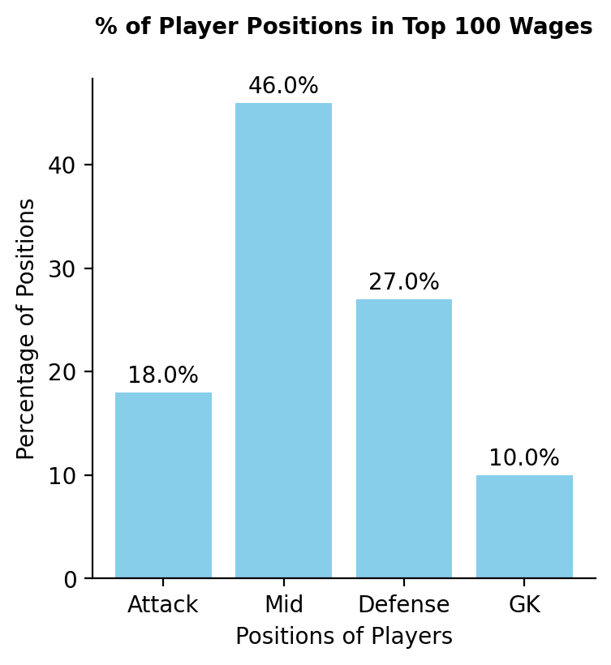

```python
# Categorize the positions.
Attack = round(rich_100['club_position'].str.contains('CF|ST|RS|LS|RF|LF', na=False).sum() / rich_100['club_position'].count() * 100,0)
Mid = round(rich_100['club_position'].str.contains('RM|LM|LCM|RCM|LW|RW|CDM|CAM|CM|LDM|RDM', na=False).sum() / rich_100['club_position'].count() * 100,0)
Def = round(rich_100['club_position'].str.contains('LCB|RCB|LB|RB|LWB|RWB|CB', na=False).sum() / rich_100['club_position'].count() * 100,0)
GK = round(rich_100['club_position'].str.contains('GK', na=False).sum() / rich_100['club_position'].count() * 100,0)
positions = ['Attack', 'Mid', 'Defense', 'GK']
data1 = [Attack,Mid,Def,GK]

# Plot the distribution.
fig, axs = plt.subplots(figsize=[4,4])
axs.bar(positions, data1, color='skyblue')
for i, value in enumerate(data1):
    axs.text(i, value+0.5, f"{value}%", ha='center', va='bottom')
axs.set(xlabel='Positions of Players', ylabel='Percentage of Positions')
axs.set_title('% of Player Positions in Top 100 Wages', fontweight='bold', fontsize=10, pad = 20)
axs.spines['top'].set_visible(False)
axs.spines['right'].set_visible(False)
plt.show()
```

From the plot, we observe that midfielders dominate the *rich_100* data, followed by defenders, attackers, and goalkeepers. This order does not align with the previous trend, which showed that the median wage decreases from attackers to midfielders, defenders, and goalkeepers. This suggests that while attackers generally earn the highest wages, the *rich_100* data includes a larger number of midfielders and defenders, indicating that these positions may have a higher representation of moderately high earners.

### Overpaid or Underpaid?

Now, let's see the distribution of underpaid and overpaid positions. We will define underpaid as those above the average overall rating within the *rich_100* data but below the median wage. Meanwhile, those who are overpaid will be those below the average overall rating but above the median wage. Using this analysis, we can hopefully better understand the potential bias towards outfield players over goalkeepers.

```python
# Calculating average overall rating and median wage.
Average_overall = rich_100['overall'].mean()
Median_wage = rich_100['wage_eur'].median()
print(Average_overall)
print(Median_wage)
```

```
86.08
162500.0
```

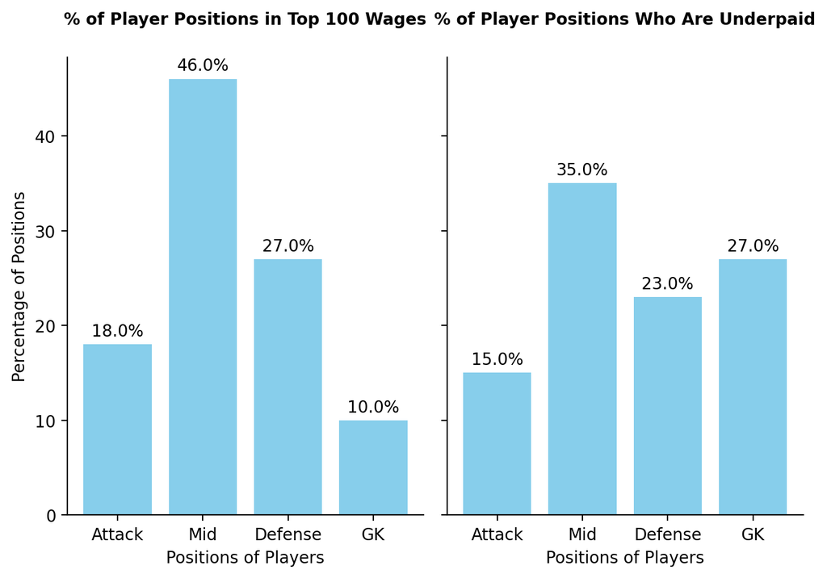

```python
# Define underpaid.
underpaid = df_filt[(df_filt['overall']>=86) & (df_filt['wage_eur']<=162500)]

# Categorize the positions.
under_striker = round(underpaid['club_position'].str.contains('CF|ST|RS|LS|RF|LF', na=False).sum() / underpaid['club_position'].count() * 100,0)
under_mid = round(underpaid['club_position'].str.contains('RM|LM|LCM|RCM|LW|RW|CDM|CAM|CM|LDM|RDM', na=False).sum() / underpaid['club_position'].count() * 100,0)
under_def = round(underpaid['club_position'].str.contains('LCB|RCB|LB|RB|LWB|RWB|CB', na=False).sum() / underpaid['club_position'].count() * 100,0)
under_gk = round(underpaid['club_position'].str.contains('GK', na=False).sum() / underpaid['club_position'].count() * 100,0)
positions = ['Attack', 'Mid', 'Defense', 'GK']
data2 = [under_striker,under_mid,under_def,under_gk]

# Plot the original distribution.
fig, axs = plt.subplots(1,2,figsize=[7,5], sharey=True)
axs[0].bar(positions, data1, color='skyblue')
for i, value in enumerate(data1):
    axs[0].text(i, value+0.5, f"{value}%", ha='center', va='bottom')
axs[0].set(xlabel='Positions of Players', ylabel='Percentage of Positions')
axs[0].set_title('% of Player Positions in Top 100 Wages', fontweight='bold', fontsize=10, pad = 20)
axs[0].spines['top'].set_visible(False)
axs[0].spines['right'].set_visible(False)

# Plot the underpaid distribution.
axs[1].bar(positions, data2, color='skyblue')
for i, value in enumerate(data2):
    axs[1].text(i, value+0.5, f"{value}%", ha='center', va='bottom')
axs[1].set(xlabel='Positions of Players')
axs[1].set_title('% of Player Positions Who Are Underpaid', fontweight='bold', fontsize=10, pad = 20)
axs[1].spines['top'].set_visible(False)
axs[1].spines['right'].set_visible(False)
plt.tight_layout()
plt.show()
```

From the figure, we can see that the percentage of positions who are underpaid is lower for all outfield players compared to the general position distribution in *rich_100* data, while the percentages of goalkeepers increased. This supports the previous analysis that outfield positions are generally favoured over goalkeepers.

Now, let's see the distribution of positions for those who are overpaid.

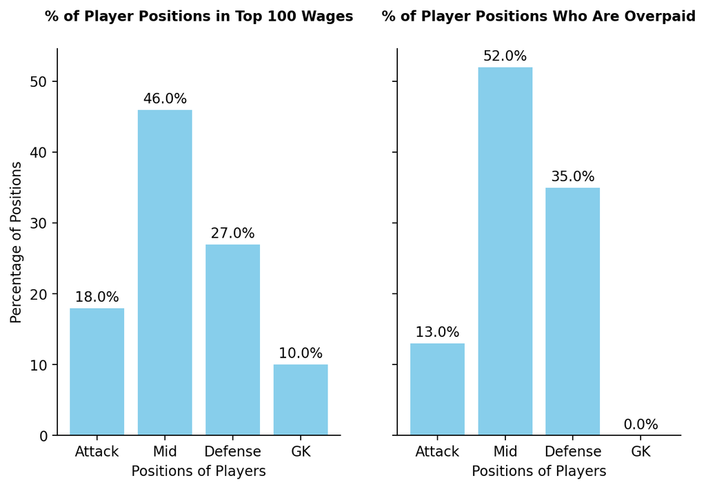

```python
# Define overpaid.
overpaid = df_filt[(df_filt['overall']<=86) & (df_filt['wage_eur']>=162500)]

# Categorize the positions.
over_striker = round(overpaid['club_position'].str.contains('CF|ST|RS|LS|RF|LF', na=False).sum() / overpaid['club_position'].count() * 100,0)
over_mid = round(overpaid['club_position'].str.contains('RM|LM|LCM|RCM|LW|RW|CDM|CAM|CM|LDM|RDM', na=False).sum() / overpaid['club_position'].count() * 100,0)
over_def = round(overpaid['club_position'].str.contains('LCB|RCB|LB|RB|LWB|RWB|CB', na=False).sum() / overpaid['club_position'].count() * 100,0)
over_gk = round(overpaid['club_position'].str.contains('GK', na=False).sum() / overpaid['club_position'].count() * 100,0)
positions = ['Attack', 'Mid', 'Defense', 'GK']
data = [over_striker,over_mid,over_def,over_gk]

# Plot the original distribution.
fig, axs = plt.subplots(1,2,figsize=[8,5], sharey=True)
axs[0].bar(positions, data1, color='skyblue')
for i, value in enumerate(data1):
    axs[0].text(i, value+0.5, f"{value}%", ha='center', va='bottom')
axs[0].set(xlabel='Positions of Players', ylabel='Percentage of Positions')
axs[0].set_title('% of Player Positions in Top 100 Wages', fontweight='bold', fontsize=10, pad = 20)
axs[0].spines['top'].set_visible(False)
axs[0].spines['right'].set_visible(False)

# Plot the overpaid distribution.
axs[1].bar(positions, data, color='skyblue')
for i, value in enumerate(data):
    axs[1].text(i, value+0.5, f"{value}%", ha='center', va='bottom')
axs[1].set(xlabel='Positions of Players')
axs[1].set_title('% of Player Positions Who Are Overpaid', fontweight='bold', fontsize=10, pad = 20)
axs[1].spines['top'].set_visible(False)
axs[1].spines['right'].set_visible(False)
plt.show()
```

The overpaid figure shows that none of the goalkeepers are considered overpaid. Therefore, the underpaid and overpaid figures demonstrate the bias of favoring outfield positions (attack, mid, defense) compared to goalkeepers within soccer.

### Distribution of Club Rank and Wage

Let’s examine the distribution of club ranks that players belong to within the rich_100 data frame.

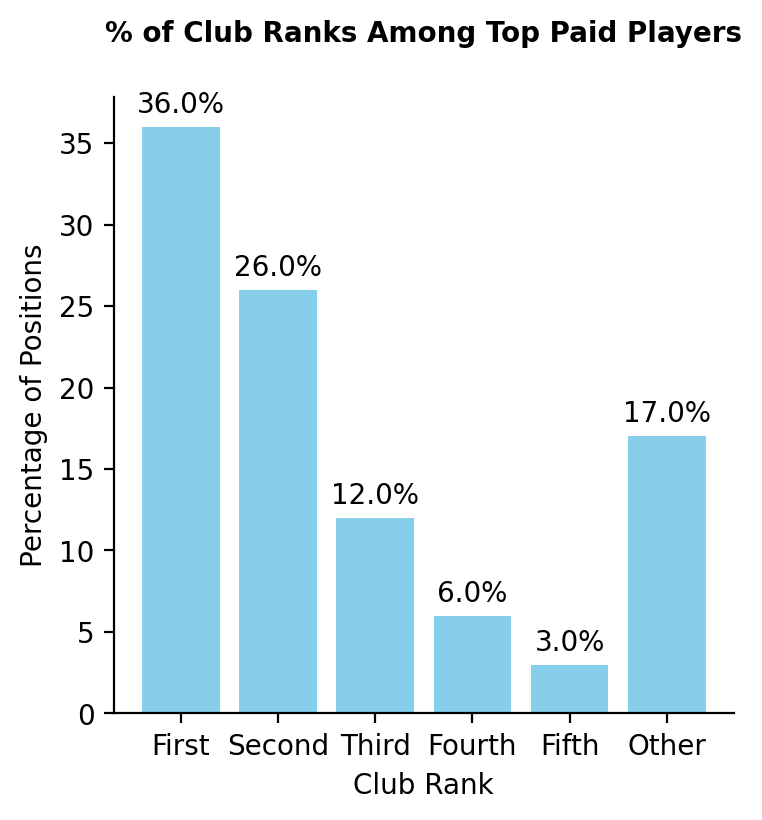

```python
# Define club ranks
Num1 = round((rich_100['club_rank']==1).sum() / rich_100['club_rank'].count() * 100,0)
Num2 = round((rich_100['club_rank']==2).sum() / rich_100['club_rank'].count() * 100,0)
Num3 = round((rich_100['club_rank']==3).sum() / rich_100['club_rank'].count() * 100,0)
Num4 = round((rich_100['club_rank']==4).sum() / rich_100['club_rank'].count() * 100,0)
Num5 = round((rich_100['club_rank']==5).sum() / rich_100['club_rank'].count() * 100,0)
Num6 = round((rich_100['club_rank']>5).sum() / rich_100['club_rank'].count() * 100,0)

# Plot the distribution
positions = ['First', 'Second', 'Third', 'Fourth', 'Fifth', 'Other']
data = [Num1,Num2,Num3,Num4,Num5,Num6]
fig, axs = plt.subplots(figsize=[4,4])
axs.bar(positions, data, color='skyblue')
for i, value in enumerate(data):
    axs.text(i, value+0.5, f"{value}%", ha='center', va='bottom')
axs.set(xlabel='Club Rank', ylabel='Percentage of Positions')
axs.set_title('% of Club Ranks Among Top Paid Players', fontweight='bold', fontsize=10, pad = 20)
axs.spines['top'].set_visible(False)
axs.spines['right'].set_visible(False)
plt.show()
```

The figure shows that 83% of the top 100 highest wage-earning players belong to the top 5 teams. This is expected, as the top 5 teams typically generate the highest revenue, enabling them to afford these players.

### Wages and Distribution of Different Teams

Finally, let's see how the wage distribution changes among teams in different ranks. We will define *top_teams* as teams whose club ranks are less than or equal to 7, *middle_teams* as those ranked between 8 and 13, and *bottom_teams* as all other teams.

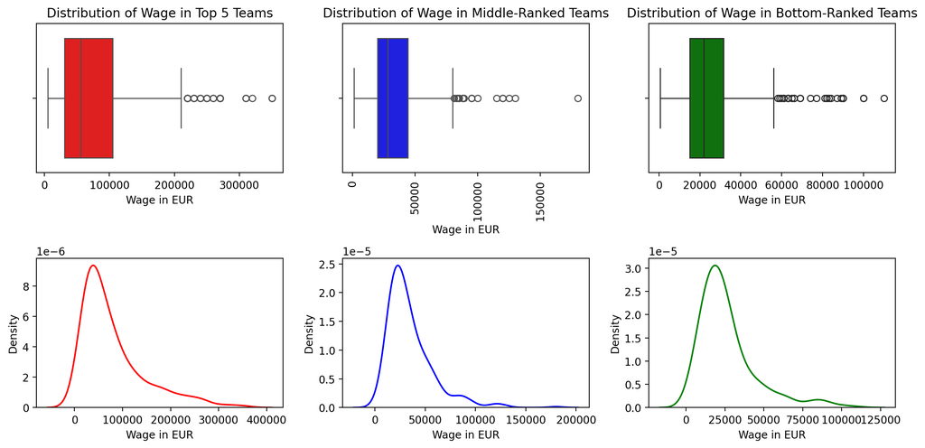

```python
# Define the variables
top_5_teams = df_filt[df_filt['club_rank']<=7]
middle_teams = df_filt[(df_filt['club_rank']>7) & (df_filt['club_rank']<14)]
bottom_teams = df_filt[(df_filt['club_rank']>=14)]

# Plot the density distribution
fig, axs = plt.subplots(2,3, figsize=[12,6])
sns.boxplot(data=top_5_teams, x='wage_eur', color='red', ax=axs[0,0])
sns.boxplot(data=middle_teams, x='wage_eur', color='blue', ax=axs[0,1])
sns.boxplot(data=bottom_teams, x='wage_eur', color='green', ax=axs[0,2])
sns.kdeplot(data=top_5_teams, x='wage_eur', color='red', ax=axs[1,0])
sns.kdeplot(data=middle_teams, x='wage_eur', color='blue', ax=axs[1,1])
sns.kdeplot(data=bottom_teams, x='wage_eur', color='green', ax=axs[1,2])
axs[0,0].set_xlabel('Wage in EUR')
axs[0,0].set_title('Distribution of Wage in Top 5 Teams')
axs[0,1].set_xlabel('Wage in EUR')
axs[0,1].set_title('Distribution of Wage in Middle-Ranked Teams')
axs[0,1].tick_params(axis='x', rotation=90)
axs[0,2].set_xlabel('Wage in EUR')
axs[0,2].set_title('Distribution of Wage in Bottom-Ranked Teams')
axs[1,0].set_xlabel('Wage in EUR')
axs[1,1].set_xlabel('Wage in EUR')
axs[1,2].set_xlabel('Wage in EUR')
plt.tight_layout()
plt.show()
```

As expected, higher-ranked teams earn greater wages, and we also observe a positively skewed distribution across all plots. This indicates that, in general, wages are unevenly distributed among all teams, with a much smaller number of players earning exceptionally high wages compared to the majority, who earn relatively similar wages.

There is an interesting trend where the number of outliers earning high wages increases as the team rank increases. This suggests that higher-ranked teams tend to have more evenly distributed player wages, while lower-ranked teams have multiple players earning significantly more than the upper quartile. This pattern aligns with lower-ranked teams' strategy, which may invest heavily in a few all-star players to enhance team quality. In contrast, higher-ranked teams typically consist of a larger roster of evenly compensated all-stars, contributing to their overall strength and balance.

### Conclusion

From the comparison of wages and positions, we observe that outfield players are favoured over goalkeepers. Additionally, although higher-ranked teams contain more players who earn higher wages and have players with wages that are more evenly distributed, the positively-skewed distribution of wages among players is present in all groups.

## Limitations

- The ratings and statistics of players are likely influenced by their performance during the season. However, the current dataset lacks key performance metrics such as goals, assists, and match ratings, limiting the ability to analyze and hypothesize how overall ratings are calculated.
- The value and ratings of players may also be influenced by the players' legacy. However, due to a lack of previous records of players, this also could not be accounted for.
- Therefore, future research is recommended to include the player performance statistics and compare the current data set to previous data sets to grasp the full picture of the player and their statistics.